# Electricity Prices & Renewable Generation

Ebba Mark

2026-04-10

# Overview

**Data:** The below documents the data currently pulled to attempt a preliminary mean model of hourly wholesale electricity prices in Germany:  
* *Wholesale Electricity Prices* (Hourly - EMBER)  
* *Electricity Demand/Load* (Hourly - ENTSOE)  
* *Electricity Generated by Energy Source* (Hourly - ENTSOE)  
* *Various Commodity Price Indices* (Monthly - IMF)  
* *Total and Country-Specific Net imports* (Hourly - ENTSOE)  
* *Day-ahead Solar and Wind Forecasts* (Hourly - ENTSOE)  
* *Redispatching Costs* (“Hourly” - netztransparenz.de - they are reported at a particular hour but are contracted for “implementation” over a certain multi-hour period, I think…as mentioned, to be investigate more)

Data that remains to be integrated:  
* *Auction Bid Data* (Data on electricity auction bids - this would likely 1. help us determine if renewables set the market price (if ever) and 2. the variability in generation costs of fossil fuel providers)  
* *Economic Activity* (GDP or VAT)

**Data Issues:** Several data issues cropped up in the process. I note the most glaring issues in **bold** throughout this notebook. Notably, the main issues are:  
* the lower-frequency of certain candidate explanatory variables (ie. fuel and non-fuel commodity prices and redispatching costs)  
* missing data on net imports from France and Denmark in specific years (data exists but is not complete)  
* we need to decide how to summarise redispatching costs correctly/appropriately. We have data on the negative and positive redispatching costs (in most cases, a postive redispatching request is offset via a negative redispatching request elsewhere.)  
* I have not log-transformed the price level or net imports as they have negative values. We should decided how to log-transform them.

**Model Attempt:** Preliminary model attempt bringing this data together using gets under the “approaching a model…” tab.

**Additional thoughts:** Though, ultimately, it would be very interesting to broaden to a multi-country scope (especially if this might allow for some comparative analysis on variable country-specific shares of renewable electricity generation), we decided to focus on Germany as a first case to see how we go. If/when we take the step to further countries, any data that I pull from ENTSO-E has an accompanying scraping script that could (reasonably) easily be repurposed to pull the identical data on other countries.

## **Start simple: Germany Only**

### **Data**

Using data from [EMBER](https://ember-energy.org/data/european-wholesale-electricity-price-data/) on European wholesale electricity prices (hourly - daily and monthly also exist). The hourly prices are the day-ahead wholesale prices in Germany. This now includes labels for the Covid-19 period, Russia-Ukraine War, and Iran War. The Covid-19 indicator spans from March 22, 2020 (Germany’s first declared lockdown) - March 20, 2022 (end of all restrictions). This endpoint should likely be a little earlier as the repeal of restrictions followed a “return to normalcy”. Alternatively, we could also link this to the four waves (Second wave: start August 2020; Third wave: start January 6, 2021; Fourth wave: start June 2021) finding reasonable end points for each. The Ukraine and Iran wars starts from the day of the first invasion/attack.

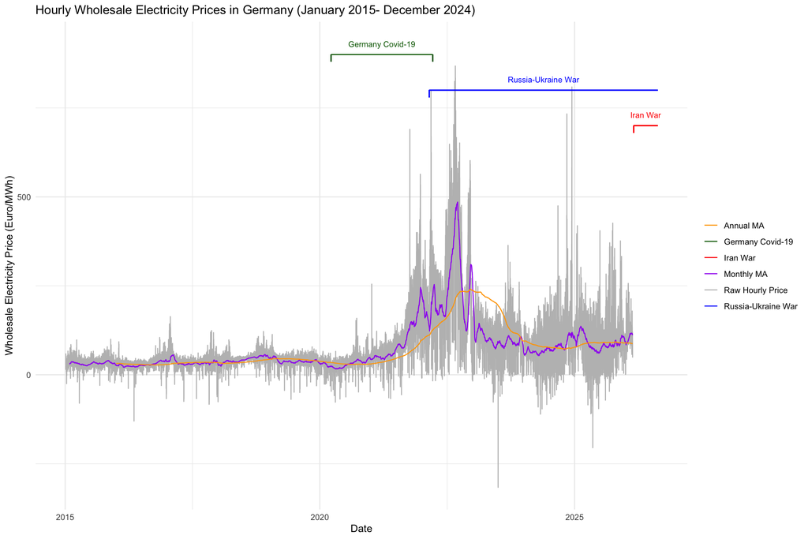

#### **Electricity Demand/Load**

Total load per bidding zone per market time unit - in our case, total load, per country, per hour in MW.

[Source](https://transparency.entsoe.eu/content/static_content/Static%20content/knowledge%20base/data-views/load-domain/Data-view%20Total%20Load%20-%20Day%20Ahead%20-%20Actual.html)

The following is data from [ENTSO-E](https://www.entsoe.eu/data/power-stats/) on hourly electricity loads.

Components: Actual total load (including losses without stored energy) = net generation – exports + imports – absorbed energy

Something interesting happens in December of every year, holiday closures or a data issue?

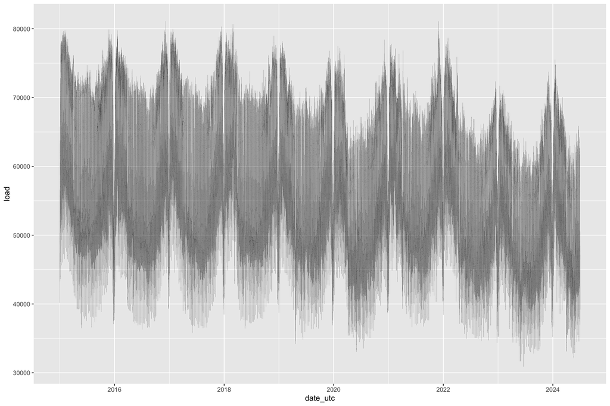

#### **Generation by Resource**

Actual Generation per Production Type from [ENTSOE](https://transparency.entsoe.eu/content/static_content/Static%20content/knowledge%20base/data-views/generation/Data-view%20Actual%20Generation%20per%20Production%20Unit.html) This value represents the actual aggregated net generation output in MW per market time unit (hour) and per production type.

**Note: There is 1 observation missing per year (either 0 or NA) on a late day in march at 2 am….a cleaning issue? Something silly?**

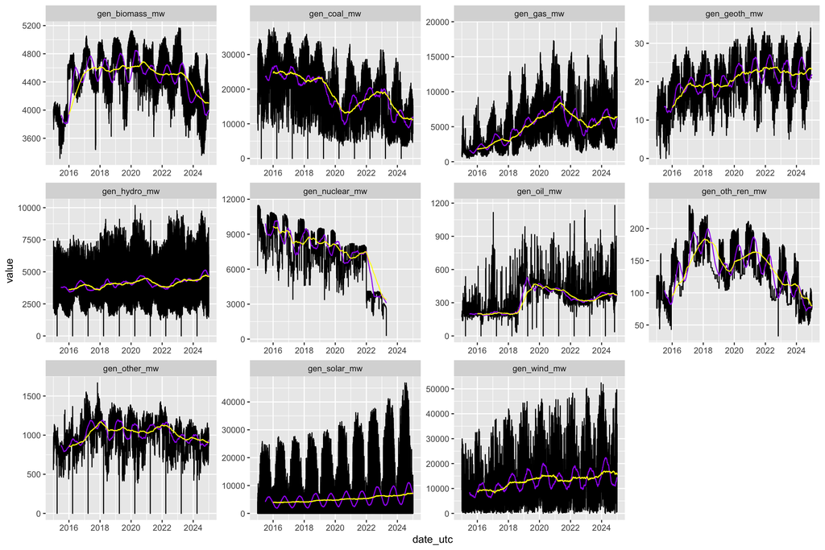

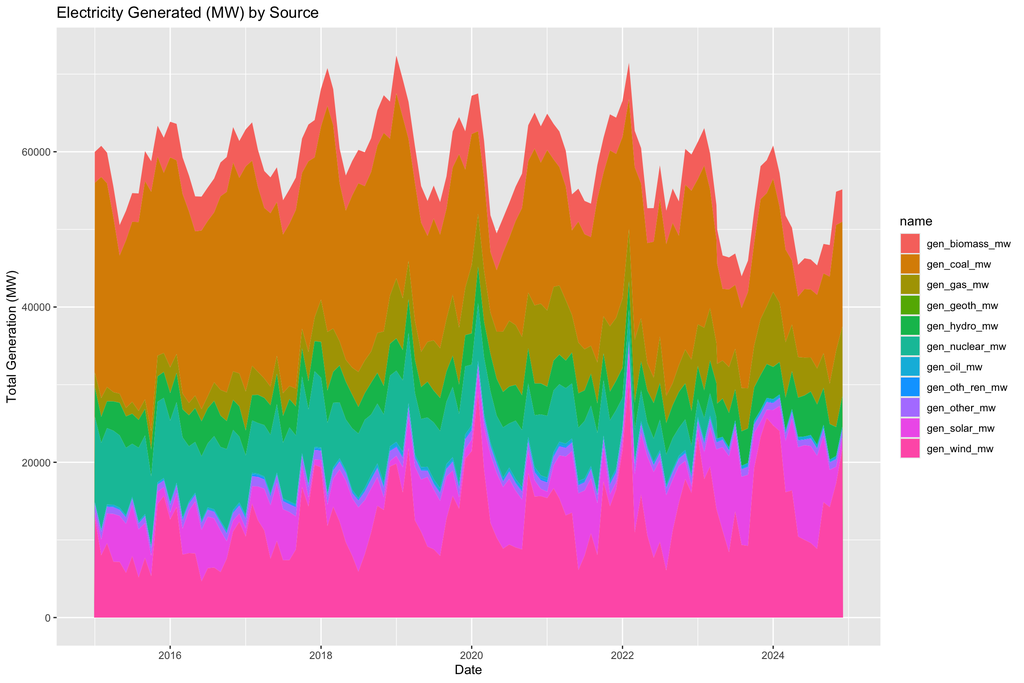

#### **Fuel and Commodity Prices**

IMF provides *monthly* commodity prices and price indices.  
Source: https://www.imf.org/en/Research/commodity-prices

The commodity prices listed below are:

**Note: These are MONTHLY values. I fill these values to hourly when merging the data later on.**

I include the following three commodity prices in the model selection for now (final plot in this section):  
* Natural Gas Price, Netherlands TTF Natural Gas Forward Day Ahead, US$ per Million Metric British Thermal Unit  
* Fuel & Non-Fuel Commodities Price Index: All Commodity Price Index, 2016 = 100, includes both Fuel and Non-Fuel Price Indices  
* Indust. Input Price: Industrial Inputs Price Index, 2016 = 100, includes Agricultural Raw Materials and Base Metals Price Indices

**Note: We should probably rethink the non-natural gas prices (the latter two indices). The two latter indices are global indices and given the industrial structure of Germany we might want to consider a Producer Price Index for Germany specifically, assuming that exists? Additionally, as you can see in the graph, the latter two essentially trace each other/collinearity issues.**

| Commodity Type | Index Label (in plots) | Index Definition | Index Unit (USD or Index) |
| --- | --- | --- | --- |
| Coal | Coal | Coal Price Index, 2016 = 100, includes Australian and South African Coal | Index |
| Gas | Nat. Gas (NDL TTF) | Natural Gas, Netherlands TTF Natural Gas Forward Day Ahead, US$ per Million Metric British Thermal Unit | USD |
| Oil | Oil - Avg Brent, West TX, Dubai (USD) | Crude Oil (petroleum), Price index, 2016 = 100, simple average of three spot prices; Dated Brent, West Texas Intermediate, and the Dubai Fateh | USD |
| Oil | Oil - Brent | Crude Oil (petroleum), Dated Brent, light blend 38 API, fob U.K., US$ per barrel | USD |
| Oil | Oil - Dubai | Crude Oil (petroleum), Dubai Fateh Fateh 32 API, US$ per barrel | USD |
| Oil | Oil - West TX | Crude Oil (petroleum), West Texas Intermediate 40 API, Midland Texas, US$ per barrel | USD |
| Oil | Oil - Avg Brent, West TX, Dubai | Crude Oil (petroleum), Price index, 2016 = 100, simple average of three spot prices; Dated Brent, West Texas Intermediate, and the Dubai Fateh | Index |
| Gas | Nat. Gas Henry Hub | Natural Gas, Natural Gas spot price at the Henry Hub terminal in Louisiana, US$ per Million Metric British Thermal Unit | USD |
| Composite Commodity Indices | Indust. Input Price | Industrial Inputs Price Index, 2016 = 100, includes Agricultural Raw Materials and Base Metals Price Indices | Index |
| Composite Commodity Indices | Fuel (Energy - oil, ng, coal, propane) | Fuel (Energy) Index, 2016 = 100, includes Crude oil (petroleum), Natural Gas, Coal Price and Propane Indices | Index |
| Gas | Nat. Gas (Euro, Jap, American) | Natural Gas Price Index, 2016 = 100, includes European, Japanese, and American Natural Gas Price Indices | Index |
| Gas | Nat. Gas (Indonesian LNG in Japan) | Natural Gas, Indonesian Liquefied Natural Gas in Japan, US$ per Million Metric British Thermal Unit | USD |
| Composite Commodity Indices | Fuel & Non-Fuel Commodities | All Commodity Price Index, 2016 = 100, includes both Fuel and Non-Fuel Price Indices | Index |
| Nrg. Transition Input Material Prices | Nrg. Transition Metals Composite | Energy Transition Metal Index | Index |
| Nrg. Transition Input Material Prices | Battery-Grade Lithium | Lithium Metal =99%, Battery Grade | USD |
| Nrg. Transition Input Material Prices | Manganese | Manganese Electro CIF NWE (US$ perMT) | USD |
| Nrg. Transition Input Material Prices | Rare Earth Carbonate | Rare Earth Carbonate REO 42-45 Dom. | USD |
| Nrg. Transition Input Material Prices | Silicon Lumps | Silicon Lumps CIF NWE (US$ perMT) | USD |
| Nrg. Transition Input Material Prices | Vanad. Pentox. | Vanadium Pentoxide CIF NWE | USD |

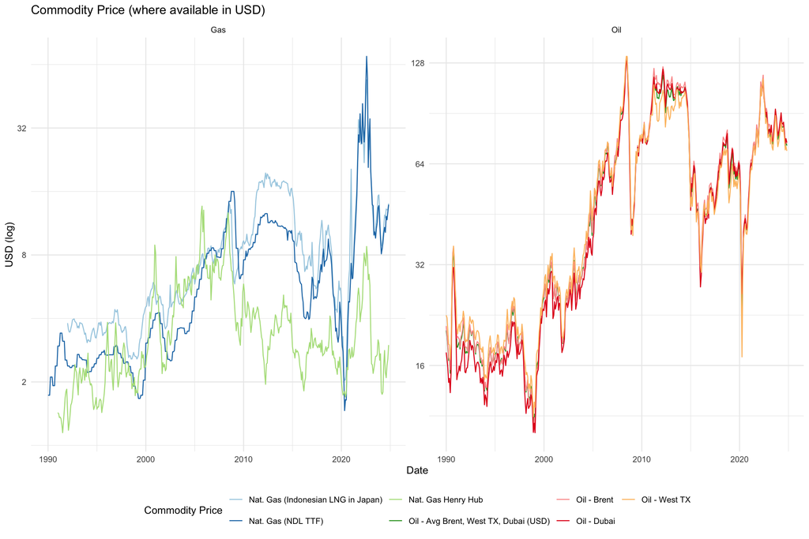

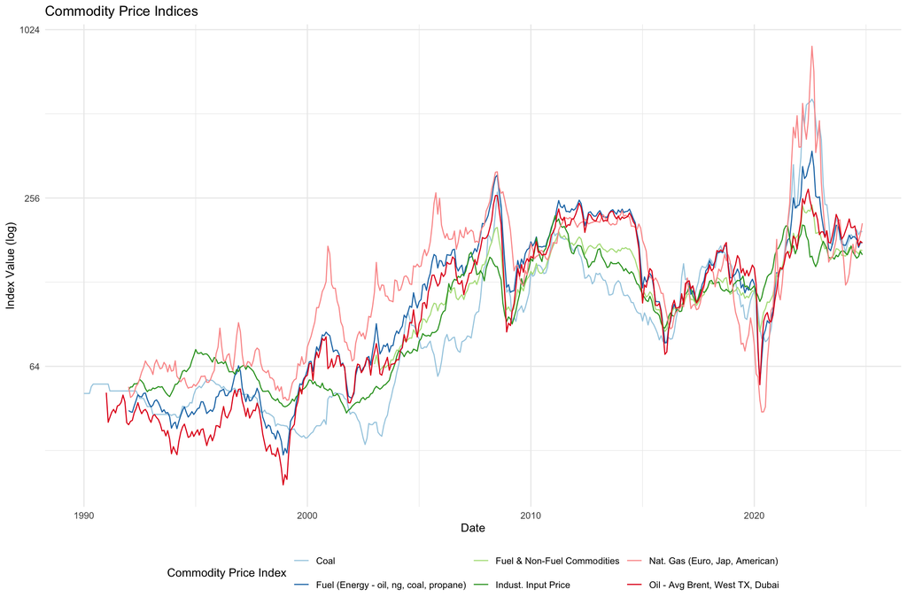

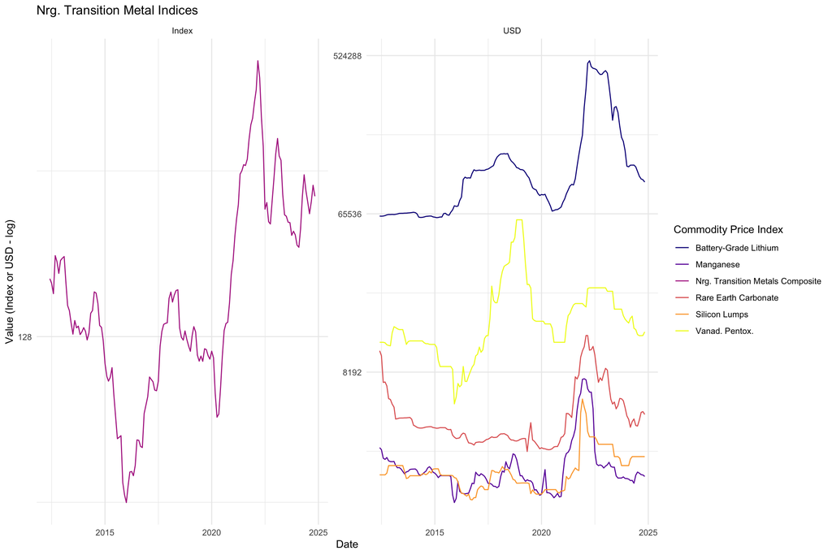

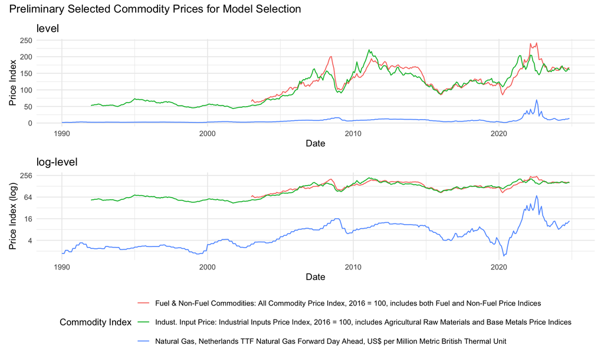

#### **Net Imports**

Imports and export flows of electricity from [ENTSOE Transparency Platform](https://transparency.entsoe.eu/content/static_content/Static%20content/knowledge%20base/data-views/transmission-domain/Data-view%20Cross%20Border%20Physical%20Flows.html).  
Physical flows between bidding zones per market time unit.  
Physical flow is defined as the measured real flow of energy between neighbouring bidding zones on the cross borders.

**Note 1: Net imports still has some missing data and I’m not quite sure where it comes from (see Austria, Denmark, France, Switzerland).**  
**Note 2: Also, the seeming upper and lower limits must have to do with capacity constraints on imports and exports (see Belgium, Norway, Sweden).**

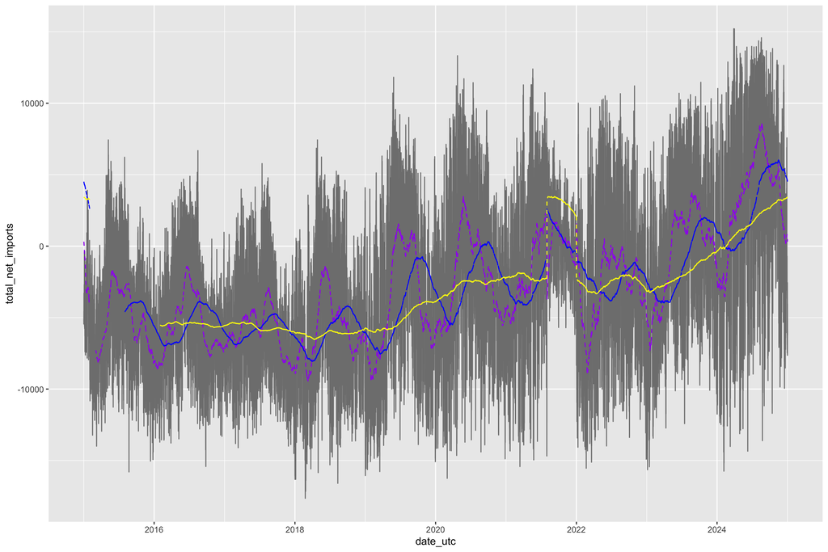

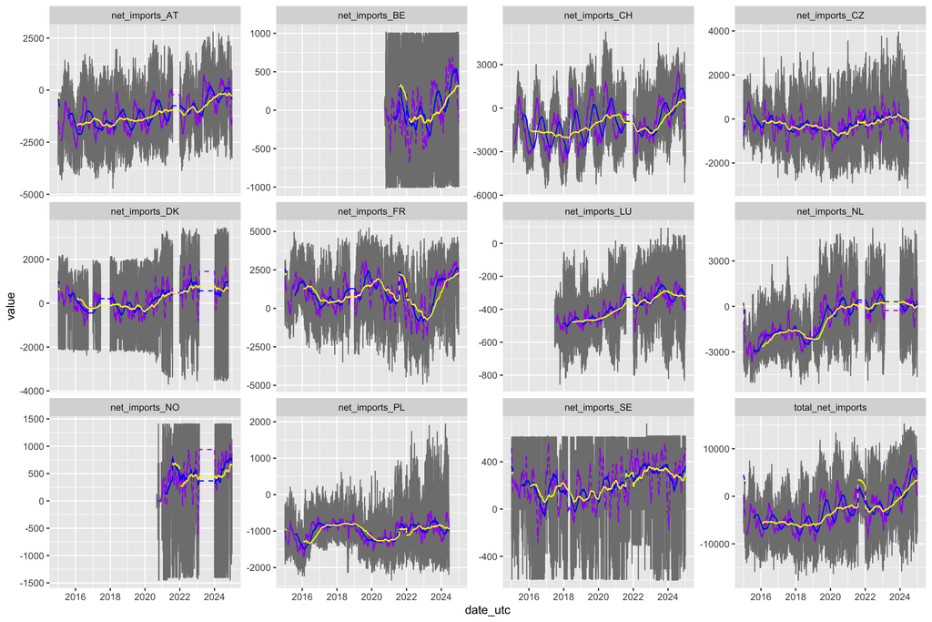

#### **Day-ahead Solar and Wind Forecasts**

A forecast of wind and solar power generation (MW) per country per hour of the following day data from [ENTSOE Transparency Platform](https://transparency.entsoe.eu/content/static_content/Static%20content/knowledge%20base/data-views/generation/Data-view%20Generation%20Forecasts%20-%20Day%20Ahead%20for%20Wind%20and%20Solar.html).

**Note: we need to consider the logical link between these forecasts and price-setting/auction behaviour.**

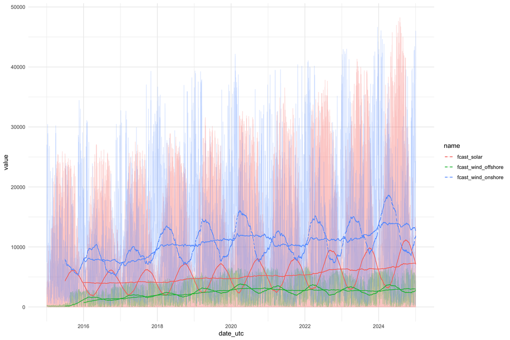

#### **Redispatching Costs**

##### Overview

Four transmission system operators (TSOs) in Germany actively monitor the contracted transmission of electricity in the grid to ensure load-balancing “in the event of imminent overloads in the electricity grid.”

“Redispatch is a request to adjust the active power feed-in of plants (conventional power plants, CHP plants, renewable energy plants, storage facilities) by the grid operator with the aim of avoiding or eliminating any bottlenecks that occur. This measure can be applied within and across control areas. By reducing the active power feed-in of one or more systems while simultaneously increasing the active power feed-in of one or more other systems, the total active power feed-in remains almost unchanged while at the same time relieving a bottleneck.” ([NETZTRANSPARENZ.DE](https://www.netztransparenz.de/en/Ancillary-Services/System-operations/Redispatch%5D)).

*Note: This information is also available from [ENTSO-E](https://transparency.entsoe.eu/congestion-management/r2/redispatching-internal/show), however NETZTRANSPARENZ.DE handles the aggregation across the German TSOs. If we used ENTSOE we would have to figure out the aggregation ourselves. Therefore, I proceed with the Netztransparenz data.*

([NETZTRANSPARENZ.DE](https://www.netztransparenz.de/en/Ancillary-Services/System-operations/Redispatch%5D)) provide data on redispatching for each individual requested measure/adjustment. Because these measures can be planned for implementation over more than a one-hour period, Netztransparenz provides three aggregated metrics per request (max MW power reduced or increased in any quarter-hour; average MW power reduced or increased per quarter-hour (excluding quarter-hours where no power was reduced or increased); and total work of the request in MWh). Because the MWh value is additive, this is the most useful and I proceed with this. We could consider using the max power as a measure of stress, but we would need to consider what time period to attribute it to, which is challenging for multi-hour or multi-quarter-hour implementation windows. For example, a redispatching measure spanning a 5-hour period would report a single max MW value reduced or increased per quarter-hour. However, this cannot be attributed to a precise quarter-hour or even hour. So we would have to be careful with it.

To arrive at “accurate” hourly observations, I summarise each mechanisms reported values by quarter-hour and hour:

1. I expand a single redispatching event into its quarter-hour windows from the reported start time to end time. Then, divide the event’s total MWh by the number of quarters (total MWh/n_quarters) to get a quarter-hour MWh value.

*Result:* Dataframe of redispatching work by quarter-hour.

2. Convert each quarter hour to its hourly floor (21.15 -> 21.00), add the total MWh across the quarter hours. This conversion from expanded quarter-hour is required before going to hourly level as start and end times of redispatching events are not always reported at even hours. For example, applying MWh value from a 45-minute to a 1-hour period could lead to an over-estimation of total MWh.

*Result:* Dataframe of redispatching work by hour.

##### Missing Data

First, some notes on missing data.

###### Minor Issues

I make some modifications/exclusions in the data after further investigation:

In total, these exclusions remove 3.5% of the original, raw sample. I think this is reasonable. The only thing to consider is whether we wish to include tests/probefahrter. The below table indicates how much data is removed for each year of the series.

Summary of Removed/Cleaned Observations

| Year | NA Energy Type | NULL Redispatch Reason | Tests | Incorrect Start/End Time | N Removed (Likely Errors) | N Removed (Total incl. Tests) | % Sample Removed | % Sample Remaining |
| --- | --- | --- | --- | --- | --- | --- | --- | --- |
| 2013 | 0 | 0 | 0 | 29 | 29 | 29 | 0.02% | 99.98% |
| 2014 | 0 | 0 | 0 | 75 | 75 | 75 | 0.06% | 99.91% |
| 2015 | 3 | 0 | 0 | 2 | 5 | 5 | 0% | 99.91% |
| 2016 | 15 | 11 | 0 | 1 | 27 | 27 | 0.02% | 99.89% |
| 2017 | 37 | 16 | 0 | 2 | 55 | 55 | 0.05% | 99.84% |
| 2018 | 14 | 0 | 0 | 0 | 14 | 14 | 0.01% | 99.83% |
| 2019 | 2 | 0 | 13 | 0 | 2 | 15 | 0.01% | 99.81% |
| 2020 | 2 | 0 | 290 | 0 | 2 | 292 | 0.25% | 99.57% |
| 2021 | 0 | 0 | 505 | 0 | 0 | 505 | 0.43% | 99.14% |
| 2022 | 0 | 0 | 490 | 0 | 0 | 490 | 0.41% | 98.73% |
| 2023 | 0 | 0 | 757 | 0 | 0 | 757 | 0.64% | 98.09% |
| 2024 | 4 | 0 | 831 | 0 | 4 | 835 | 0.7% | 97.39% |
| 2025 | 0 | 0 | 892 | 0 | 0 | 892 | 0.75% | 96.63% |
| 2026 | 0 | 0 | 163 | 0 | 0 | 163 | 0.14% | 96.5% |

###### Major Issue

Another more consequential note on missing data. When aggregating, we rely on the “work_mwh” variable (total mwh work per redispatch measure). This value is missing for several observations, affecting ~20% of our sample which is a big chunk! The table below displays how many observations (individual redispatch measures) are removed from the raw sample because of a missing value for total work in MWh.

Summary of Genuine Missing Summary Observations

| Year | NA Work MWh | % Sample Removed | % Sample Remaining | NA Work MWh (avg_mw exists) | Possible Recoverable % Sample | NA Avg MW | Relying on Avg MW Only % Sample Remaining |
| --- | --- | --- | --- | --- | --- | --- | --- |
| 2013 | 1 | 0% | 100% | 1 | 100% | 0 | 100% |
| 2014 | 0 | 0% | 100% | 0 | 100% | 0 | 100% |
| 2015 | 27 | 0.02% | 99.98% | 27 | 99.98% | 1 | 100% |
| 2016 | 243 | 0.2% | 99.77% | 62 | 99.92% | 521 | 99.56% |
| 2017 | 693 | 0.58% | 99.19% | 191 | 99.76% | 1218 | 98.53% |
| 2018 | 863 | 0.73% | 98.46% | 248 | 99.55% | 1136 | 97.57% |
| 2019 | 692 | 0.58% | 97.88% | 177 | 99.4% | 952 | 96.77% |
| 2020 | 1473 | 1.24% | 96.63% | 340 | 99.12% | 1976 | 95.1% |
| 2021 | 2420 | 2.04% | 94.59% | 493 | 98.7% | 3361 | 92.27% |
| 2022 | 3356 | 2.83% | 91.76% | 615 | 98.18% | 4726 | 88.28% |
| 2023 | 3537 | 2.98% | 88.78% | 661 | 97.63% | 4841 | 84.2% |
| 2024 | 3678 | 3.1% | 85.67% | 663 | 97.07% | 5289 | 79.74% |
| 2025 | 4168 | 3.52% | 82.16% | 724 | 96.46% | 5470 | 75.12% |
| 2026 | 1178 | 0.99% | 81.16% | 162 | 96.32% | 1571 | 73.8% |

##### Data Presentation

Finally, below I use the hourly series (excluding the missing data mentioned above and computed using the quarter-hourly disaggregation followed by hourly aggregation described above), to plot the data. The plots below show the associated “redispatching work” by primary energy type (conventional, renewable, and miscellaneous (“sonstiges”)). The vertical line indicates the start of Redispatch 2.0, whereing RES plants were considered viable for redispatching action.

**Remaining questions:**

- By design, redispatching measures are meant to “reduce” and “increase” production symmetrically. We need to decide how to handle this. Report the highest, lowest, or mean of the absolute value of both/either (deally, the decrease and increase reported in each period should be identical in magnitude, but this is not always the case in the data. [Titz. et al 2024](https://doi.org/10.1016/j.apenergy.2023.122351) acknowledge the same challenge.)? Report total redispatching costs by energy type (net RES dispatch work, net conventional redispatch work)?
- Handle the ~20% missing values for the summarising variable (total MWH) of redispatching events. As noted in the second table above, we might be able to infer this from the “average MW” variable.
- All redispatching measures report a primary energy type (conventional, renewable, or miscellaneous). I do not know what “sonstiges” or “miscellaneous” includes in terms of the primary energy type. I tried having a look at the netztransparenz.de website and their glossary, but really struggled to find anything useful. Perhaps Jonas could have a look?

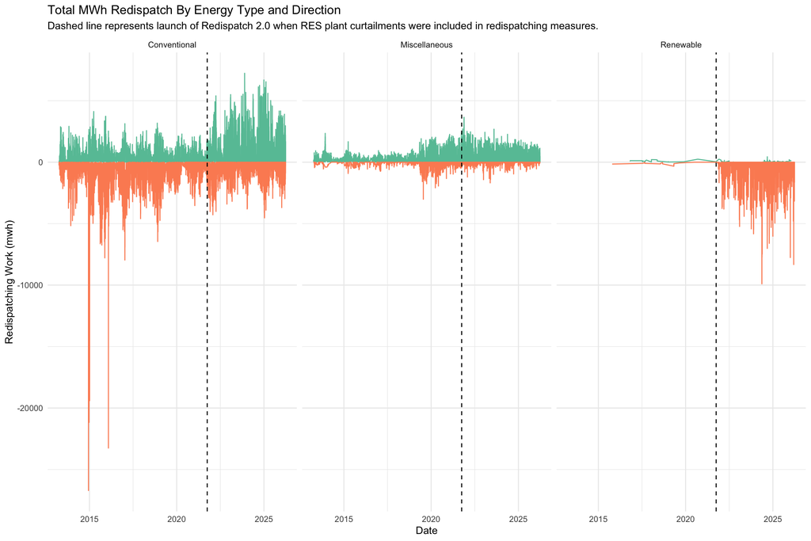

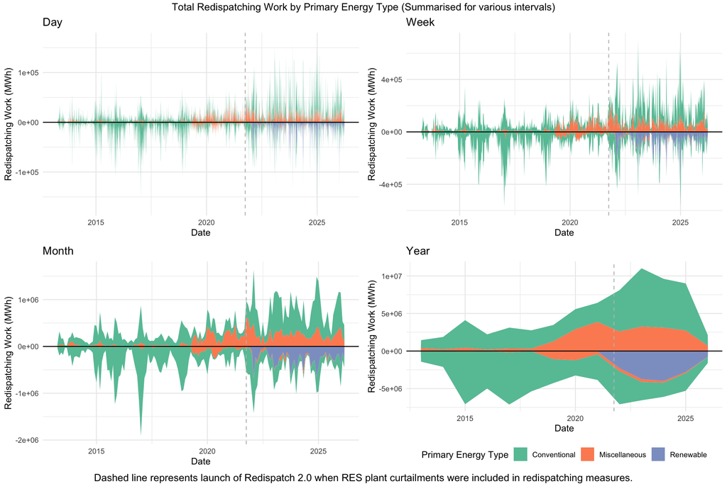

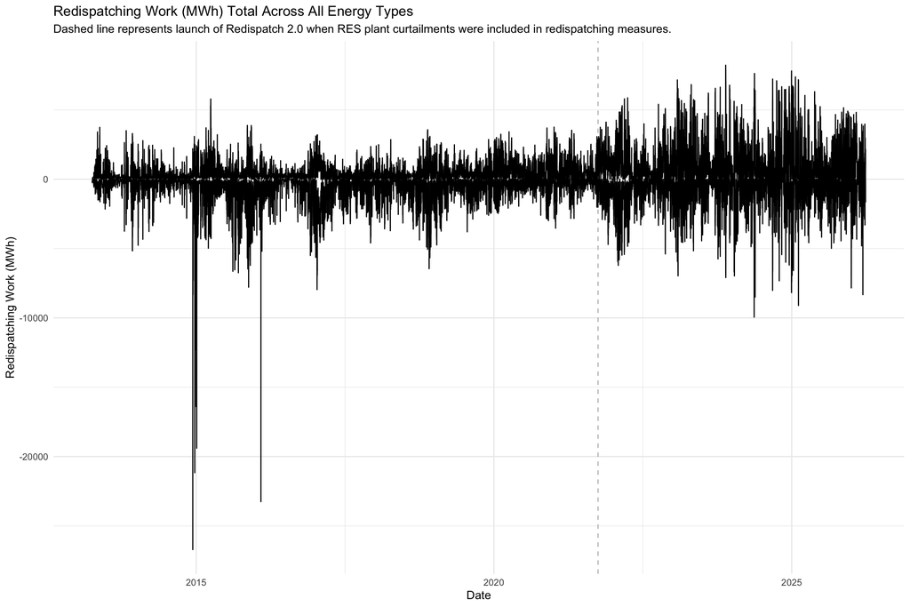

#### **Combining Data**

**Note: Potential transformation issues to discuss:**  
1. Forward-fill of monthly commodity price values  
2. To deal with 0 values for certain variables I need to log_transform the value + 1. I don’t think this is a major issue given the magnitude of these variables but worth reconsidering.  
3. **(!!)** For net imports there are several observations for country-specific flows that are NA. Most result from NA values reported for both imports and exports at those hours. However, for Denmark (1,860 obs) and France (2,234 obs) this issue results from non-NA imports and NA exports. **THIS WILL ABSOLUTELY NEED TO BE REINVESTIGATED - WE CANNOT FORMALISE ANY RESULTS WITHOUT FINDING A WAY TO DEAL WITH THIS.**

```r
de_all <- de_hourly_prices %>%
  rename(date_utc = datetime_utc) %>%
  left_join(., entsoe_de, by = c("date_utc", "country")) %>%
  left_join(., de_generation, by = c("date_utc", "country", "country_code")) %>%
  arrange(date_utc) %>%
  select(-starts_with("sum_")) %>%
  filter(date_utc < "2024-03-31 02:00:00" & !is.na(gen_biomass_mw)) %>%
  mutate(across(contains("gen"), ~log(. + 1), .names = "log_{.col}"),
         across(starts_with("gen"), ~./load, .names = "shr_{.col}"),
         log_load = log(load+1)) %>%
  left_join(., imp_exp, by = "date_utc") %>%
  mutate(across(contains("net_imports"), ~ifelse(is.na(.), 0, .)),
         shr_net_imports = total_net_imports/load) %>%
  left_join(., fcast_sw, by = "date_utc") #%>%
  #left_join(., redisp_df, by = "date_utc")

de_full <- de_all %>%
  left_join(., ng_price, by = "date_utc") %>%
  # We fill the monthly values down!
  fill(PNGASEU, .direction = "down") %>%
  fill(PALLFNF, .direction = "down") %>%
  fill(PINDU, .direction = "down") %>%
  # Given our redispatching data covers the 2015-2024 time period, it is safe to assume that NA values are 0 values. Barring the data/metric choice issues outlined in the "Redispatching Costs" tab above, of course.
  mutate(#redisp_work_mwh = ifelse(is.na(redisp_work_mwh), 0, redisp_work_mwh),
         # Create hourly and monthly dummies
        hour = as.factor(hour(datetime_local)),
         month = as.factor(month(datetime_local)),
        weekday = weekdays(datetime_local),
        #log_redisp_mwh = log(redisp_work_mwh + 1),
        log_PNGASEU = log(PNGASEU + 1),
        log_PALLFNF = log(PALLFNF + 1),
        log_PINDU = log(PINDU + 1)) %>%
  dummy_cols(select_columns = c("hour", "month", "weekday"), remove_first_dummy = TRUE, remove_selected_columns = TRUE) %>%
  mutate(covid_ind = as.numeric(date_utc >= covid_start & date_utc < covid_end),
         ukraine_ind = as.numeric(date_utc >= ukraine_war_start & date_utc < ukraine_war_end),
         iran_ind = as.numeric(date_utc >= iran_war_end & date_utc < iran_war_end))
```

### **Approaching a model…**

Note that all level variables except net imports and prices are reported in logs. Net imports and prices should be converted but they contain negative values - not sure how to handle (sign(x)*abs(x)?).

I include the following three commodity prices in the model selection for now (labels in model output in parentheses in italics):  
* Natural Gas Price: Netherlands TTF Natural Gas Forward Day Ahead, US$ per Million Metric British Thermal Unit *(Gas Price)*  
* Fuel & Non-Fuel Commodities Prices: All Commodity Price Index, 2016 = 100, includes both Fuel and Non-Fuel Price Indices. Note: this one might be problematic because it already includes fuel prices? *(Commodity Ind)*  
* Industrial Input Price: Industrial Inputs Price Index, 2016 = 100, includes Agricultural Raw Materials and Base Metals Price Indices *(Indust.Inp.Ind.)*

For each replication portion there are two levels of sub-tabs. First, whether the model is estimated using the *level* values of each relevant regressor (ie. wind, solar, fossil generation in log-mwh) or their *shares* (labelled “sh” in the regression output) of total generation in each hour. Second, for the Escribano et al. replication, I additionally include indicators for the Covid-19, Ukraine War, and Iran War periods (one tab “w.o. Indicators” and one tab “w. Indicators”). Note that for now, our time series is limited to a period prior to the attack on Iran, meaning that there is a warning of “singularity” for this regressor. It is dropped and does not affect the estimation, so I keep it (disregarding the warning) for when our time series extends longer.

#### Rintamaki et al. 2017

Below, I incorporate most explanatory variables (except solar and wind forecasts) above into models of the mean (not yet variance). The first model tab incorporates the variables simply as (log) levels whereas the second incorporates them as shares of total “load.” In each tab, I run the model with the same set of regressors to be selected over but with or without a log.ewma argument. In line with Rintamaki et al, we incorporate moving average terms for half-day, daily, and weekly price volatility (levels?) via log.ewma argument (correct?). I need to think more closely about how that functions together with the hourly and monthly dummies.

**Note: log.ewma() for half-day, daily, and weekly price volatilities? Correct idea?**  
**Note: Hourly and daily dummies the best way to incorporate “seasonality”? How might this interfere with the ewma terms?**  
**Note: I do not currently incorporate any ARCH terms.**  
**Note: day-ahead versus current prices in all variables? - are we not interested in deviations from forecasts for price-setting?**  
**Note: Finally, a basic question, but I do not currently have the output variable (hourly wholesale electricity prices) in logs as it frequently takes negative values)**

```r
# Check to make sure data is ordered
de_full %>% arrange(date_utc) %>% all.equal(de_full)
```

```
## [1] TRUE
```

##### Levels as Exp. Vars.

```r
weekday_cols <- names(select(de_full, contains("weekday")))

var_labels <- c(
  "log_load"            = "Load",
  "log_gen_gas_mw"      = "Gas gen.",
  "log_gen_coal_mw"     = "Coal gen.",
  "log_gen_hydro_mw"    = "Hydro gen.",
  "log_gen_geoth_mw"    = "Geothermal gen.",
  "log_gen_nuclear_mw"  = "Nuclear gen.",
  "log_gen_oth_ren_mw"  = "Other renewbls",
  "log_gen_solar_mw"    = "Solar gen.",
  "log_gen_wind_mw"     = "Wind gen.",
  "log_PNGASEU"         = "Gas Price",
  "log_PALLFNF"         = "Commodity Ind.",
  "log_PINDU"           = "Indust.Inp.Ind.",
  "net_imports_SE"      = "Net imports: SE",
  "net_imports_PL"      = "Net imports: PL",
  "net_imports_CZ"      = "Net imports: CZ",
  "net_imports_BE"      = "Net imports: BE",
  "net_imports_CH"      = "Net imports: CH",
  "net_imports_NO"      = "Net imports: NO",
  "net_imports_NL"      = "Net imports: NL",
  "net_imports_LU"      = "Net imports: LU",
  "net_imports_FR"      = "Net imports: FR",
  "net_imports_DK"      = "Net imports: DK",
  "net_imports_AT"      = "Net imports: AT",
  #"log_redisp_mwh"      = "Redispatch work",
   'shr_gen_gas_mw' = "Gas gen (sh)",
   'shr_gen_coal_mw' = "Coal gen (sh)",
   'shr_gen_hydro_mw' = "Hydro gen (sh)",
   'shr_gen_geoth_mw' = "Goethermal (sh)",
   'shr_gen_nuclear_mw' = "Nuclear (sh)",
   'shr_gen_oth_ren_mw' = "Other renew (sh)",
   'shr_gen_solar_mw' = "Solar gen (sh)",
   'shr_gen_wind_mw' = "Wind gen (sh)",
  'shr_net_imports' = "Net Imprts (sh)",
   setNames(paste0("Hour 0", 1:9),  paste0("hour_", 1:9)),
   setNames(paste0("Hour ", 10:24),  paste0("hour_", 10:24)),
   setNames(month.name, paste0("month_", 1:12)),
  setNames(str_remove(weekday_cols, "weekday_"), weekday_cols),
  "covid_ind" = "COVID-19",
  "ukraine_ind" = "Ukraine War",
  "iran_ind" = "Iran War"
)

gen_var_labels <- function(reg_mat_, lab_list = var_labels){
  # Renames only those labels that have a value in the lookup list - avoids an error on variable names that are not found in the lookup list
  ifelse(
  colnames(reg_mat_) %in% names(lab_list),
  var_labels[colnames(!reg_mat_)],
  colnames(reg_mat_)) %>%
    return(.)
}

lev_reg_mat <- as.matrix(select(de_full,
                                       'log_load',
                                       #'log_gen_biomass_mw',
                                       'log_gen_gas_mw',
                                       'log_gen_coal_mw',
                                       'log_gen_hydro_mw',
                                       'log_gen_geoth_mw',
                                       'log_gen_nuclear_mw',
                                       'log_gen_oth_ren_mw',
                                       'log_gen_solar_mw',
                                       'log_gen_wind_mw',
                                       'log_PNGASEU',
                                       'log_PALLFNF',
                                       'log_PINDU',
                                       contains('hour'),
                                       contains('month'),
                                       contains('weekday'),
                                       "net_imports_SE",
                                       "net_imports_PL",
                                       "net_imports_CZ",
                                       "net_imports_BE",
                                       "net_imports_CH",
                                       "net_imports_NO",
                                       "net_imports_NL",
                                       "net_imports_LU",
                                       "net_imports_FR",
                                       "net_imports_DK",
                                       "net_imports_AT",
                                       #"log_redisp_mwh"
                                       #"total_net_imports" # Excluded as its sum components are each of the net_imports above
                                       )) # 'gen_wind_mw' 'gen_coal_mw', 'gen_hydro_mw',

colnames(lev_reg_mat) <- gen_var_labels(lev_reg_mat)

rint_de_mod_levs <- arx(de_full$price_eur_m_whe,
              # Question: In theory, the ARCH(24) would proxy the seasonal (daily) AR term?
              #arch = 1:24,
              mxreg = lev_reg_mat)

rint_de_mod_levs_logewma <- arx(de_full$price_eur_m_whe,
              # As in Rintamaki et al. the below line incorporates moving average terms for the half-day (12), day (24 hours) and week (168 hours)  - correct?
              log.ewma = c(12, 24, 168),
              # Question: In theory, the ARCH(24) would proxy the seasonal (daily) AR term?
              #arch = 1:24,
              mxreg = lev_reg_mat)

# model selection and plotting of residuals
rint_de_levs_sel <- getsm(rint_de_mod_levs, ar.LjungB = NULL, arch.LjungB = NULL)
```

```
##
## GUM mean equation:
##
##                 reg.no. keep        coef   std.error    t-stat   p-value
## mconst                1    0  3.6712e+02  2.4837e+01   14.7811 < 2.2e-16 ***
## Load                  2    0  9.4395e+00  2.2608e+00    4.1752 2.980e-05 ***
## Gas gen.              3    0  2.9762e+01  4.1507e-01   71.7023 < 2.2e-16 ***
## Coal gen.             4    0 -1.0320e+01  6.9977e-01  -14.7480 < 2.2e-16 ***
## Hydro gen.            5    0 -4.2092e+00  4.9492e-01   -8.5048 < 2.2e-16 ***
## Geothermal gen.       6    0  1.5203e+01  7.3664e-01   20.6387 < 2.2e-16 ***
## Nuclear gen.          7    0 -2.3295e+01  6.9638e-01  -33.4510 < 2.2e-16 ***
## Other renewbls        8    0  1.5134e+01  7.9113e-01   19.1298 < 2.2e-16 ***
## Solar gen.            9    0  4.7231e-01  8.9896e-02    5.2539 1.493e-07 ***
## Wind gen.            10    0  4.3892e-01  2.5563e-01    1.7170 0.0859778 .
## Gas Price            11    0  8.5720e+01  9.4997e-01   90.2344 < 2.2e-16 ***
## Commodity Ind.       12    0  9.4321e+01  3.5956e+00   26.2323 < 2.2e-16 ***
## Indust.Inp.Ind.      13    0 -2.2502e+02  2.1149e+00 -106.4008 < 2.2e-16 ***
## Hour 01              14    0  5.8527e-01  9.9459e-01    0.5885 0.5562291
## Hour 02              15    0  1.7368e+00  1.0037e+00    1.7305 0.0835534 .
## Hour 03              16    0  1.3629e+00  1.0123e+00    1.3464 0.1781731
## Hour 04              17    0  2.6602e+00  1.0189e+00    2.6109 0.0090315 **
## Hour 05              18    0  5.5240e+00  1.0190e+00    5.4210 5.946e-08 ***
## Hour 06              19    0  1.2223e+01  1.0391e+00   11.7633 < 2.2e-16 ***
## Hour 07              20    0  1.7234e+01  1.0882e+00   15.8371 < 2.2e-16 ***
## Hour 08              21    0  1.4510e+01  1.1796e+00   12.3001 < 2.2e-16 ***
## Hour 09              22    0  8.3890e+00  1.3028e+00    6.4393 1.208e-10 ***
## Hour 10              23    0  3.6985e+00  1.3870e+00    2.6667 0.0076627 **
## Hour 11              24    0  1.3490e+00  1.4407e+00    0.9364 0.3490718
## Hour 12              25    0 -2.2324e+00  1.4534e+00   -1.5359 0.1245569
## Hour 13              26    0 -4.7691e+00  1.4462e+00   -3.2976 0.0009755 ***
## Hour 14              27    0 -2.4708e+00  1.4250e+00   -1.7339 0.0829431 .
## Hour 15              28    0  1.9532e+00  1.4026e+00    1.3926 0.1637590
## Hour 16              29    0  7.4553e+00  1.3752e+00    5.4214 5.931e-08 ***
## Hour 17              30    0  1.7722e+01  1.3416e+00   13.2092 < 2.2e-16 ***
## Hour 18              31    0  2.2684e+01  1.2814e+00   17.7033 < 2.2e-16 ***
## Hour 19              32    0  1.9268e+01  1.2328e+00   15.6287 < 2.2e-16 ***
## Hour 20              33    0  1.1627e+01  1.1715e+00    9.9245 < 2.2e-16 ***
## Hour 21              34    0  6.9899e+00  1.1078e+00    6.3097 2.812e-10 ***
## Hour 22              35    0  6.6487e+00  1.0480e+00    6.3444 2.246e-10 ***
## Hour 23              36    0  6.2862e-01  1.0012e+00    0.6278 0.5301073
```

[output cut: 22 more lines]

```
## Net imports: NO      59    0  4.3005e-02  4.1185e-04  104.4192 < 2.2e-16 ***
## Net imports: NL      60    0  6.7313e-03  1.3671e-04   49.2365 < 2.2e-16 ***
## Net imports: LU      61    0 -9.0302e-03  8.8553e-04  -10.1976 < 2.2e-16 ***
## Net imports: FR      62    0 -5.9442e-03  1.2452e-04  -47.7377 < 2.2e-16 ***
## Net imports: DK      63    0  1.9698e-03  1.8043e-04   10.9170 < 2.2e-16 ***
## Net imports: AT      64    0 -7.7233e-05  2.7278e-04   -0.2831 0.7770787
## ---
## Signif. codes:  0 '***' 0.001 '**' 0.01 '*' 0.05 '.' 0.1 ' ' 1
##
##
## Diagnostics:
##
##                   Chi-sq df p-value
## Ljung-Box AR(1)    66895  1       0
## Ljung-Box ARCH(1)  63332  1       0
```

```
## 13 path(s) to search
```

```
## Searching: 1 2 3 4 5 6 7 8 9 10 11 12 13
```

```
##
##   Path 1: 10 46 64 49 36 14 24 28 16 50 15
##   Path 2: 14 46 49 64 36 24 28 16 15 50 10
##   Path 3: 15 46 36 14 64 49 24 16 28 50 10
##   Path 4: 16 36 46 14 49 64 24 28 15 50 10
##   Path 5: 24 46 49 36 14 64 28 16 15 50 10
##   Path 6: 25 46 64 50 27 49 14 36 16 15
##   Path 7: 27 46 64 25 50 49 14 36 16 15
##   Path 8: 28 36 49 46 14 24 64 16 15 50 10
##   Path 9: 36 46 49 64 14 24 28 16 15 50 10
##   Path 10: 46 49 64 14 36 24 28 16 15 50 10
##   Path 11: 49 46 64 14 36 24 28 16 15 50 10
##   Path 12: 50 46 64 14 36 24 49 16 28 15 10
##   Path 13: 64 46 49 14 36 24 28 16 15 50 10
##
## Terminal models:
##
##         info(sc)    logl     n  k
## spec 1: 10.14688 -368233 72639 53
## spec 2: 10.14706 -368234 72639 54
##
## Retained regressors (final model):
##
##   mconst   Load   Gas gen.   Coal gen.   Hydro gen.   Geothermal gen.   Nuclear gen.   Other renewbls   Solar gen.   Gas Price   Commodity Ind.   Indust.Inp.Ind.   Hour 04   Hour 05   Hour 06   Hour 07   Hour 08   Hour 09   Hour 10   Hour 12   Hour 13   Hour 14   Hour 16   Hour 17   Hour 18   Hou…
##
## Messages:
##
## - 1-CUT excluded from terminals, since it does not pass the PET
```

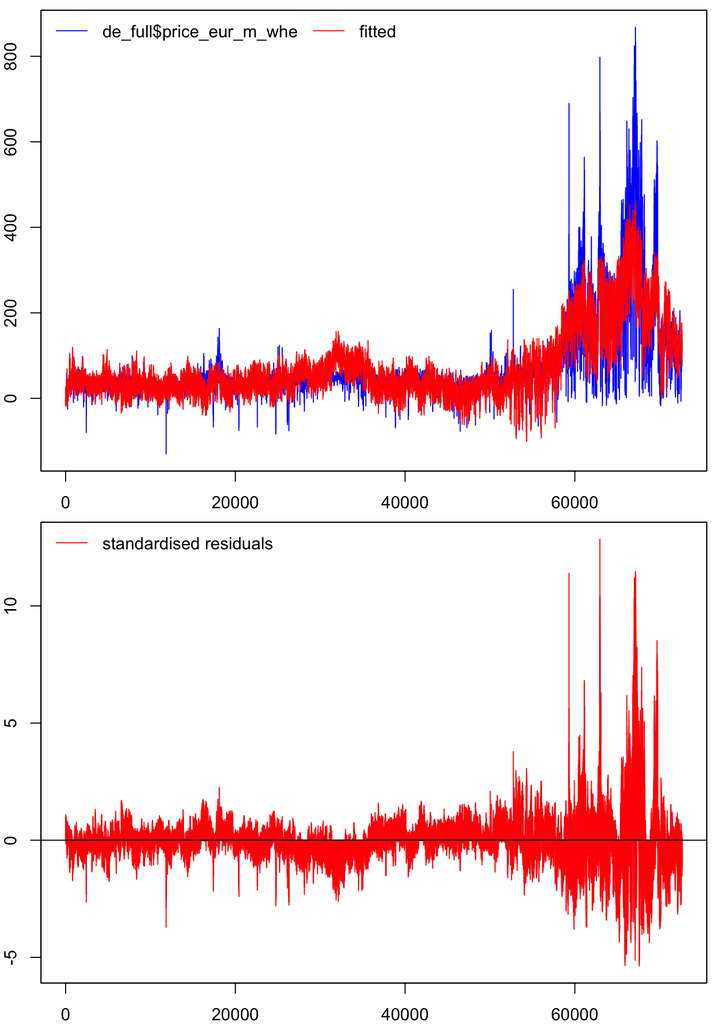

```r
rint_de_levs_sel %>% plot
```

```r
rint_de_levs_sel_logewma <- getsm(rint_de_mod_levs_logewma, ar.LjungB = NULL, arch.LjungB = NULL)
```

```
##
## GUM mean equation:
##
##                 reg.no. keep        coef   std.error    t-stat   p-value
## mconst                1    0  3.6712e+02  2.4837e+01   14.7811 < 2.2e-16 ***
## Load                  2    0  9.4395e+00  2.2608e+00    4.1752 2.980e-05 ***
## Gas gen.              3    0  2.9762e+01  4.1507e-01   71.7023 < 2.2e-16 ***
## Coal gen.             4    0 -1.0320e+01  6.9977e-01  -14.7480 < 2.2e-16 ***
## Hydro gen.            5    0 -4.2092e+00  4.9492e-01   -8.5048 < 2.2e-16 ***
## Geothermal gen.       6    0  1.5203e+01  7.3664e-01   20.6387 < 2.2e-16 ***
## Nuclear gen.          7    0 -2.3295e+01  6.9638e-01  -33.4510 < 2.2e-16 ***
## Other renewbls        8    0  1.5134e+01  7.9113e-01   19.1298 < 2.2e-16 ***
## Solar gen.            9    0  4.7231e-01  8.9896e-02    5.2539 1.493e-07 ***
## Wind gen.            10    0  4.3892e-01  2.5563e-01    1.7170 0.0859778 .
## Gas Price            11    0  8.5720e+01  9.4997e-01   90.2344 < 2.2e-16 ***
## Commodity Ind.       12    0  9.4321e+01  3.5956e+00   26.2323 < 2.2e-16 ***
## Indust.Inp.Ind.      13    0 -2.2502e+02  2.1149e+00 -106.4008 < 2.2e-16 ***
## Hour 01              14    0  5.8527e-01  9.9459e-01    0.5885 0.5562291
## Hour 02              15    0  1.7368e+00  1.0037e+00    1.7305 0.0835534 .
## Hour 03              16    0  1.3629e+00  1.0123e+00    1.3464 0.1781731
## Hour 04              17    0  2.6602e+00  1.0189e+00    2.6109 0.0090315 **
## Hour 05              18    0  5.5240e+00  1.0190e+00    5.4210 5.946e-08 ***
## Hour 06              19    0  1.2223e+01  1.0391e+00   11.7633 < 2.2e-16 ***
## Hour 07              20    0  1.7234e+01  1.0882e+00   15.8371 < 2.2e-16 ***
## Hour 08              21    0  1.4510e+01  1.1796e+00   12.3001 < 2.2e-16 ***
## Hour 09              22    0  8.3890e+00  1.3028e+00    6.4393 1.208e-10 ***
## Hour 10              23    0  3.6985e+00  1.3870e+00    2.6667 0.0076627 **
## Hour 11              24    0  1.3490e+00  1.4407e+00    0.9364 0.3490718
## Hour 12              25    0 -2.2324e+00  1.4534e+00   -1.5359 0.1245569
## Hour 13              26    0 -4.7691e+00  1.4462e+00   -3.2976 0.0009755 ***
## Hour 14              27    0 -2.4708e+00  1.4250e+00   -1.7339 0.0829431 .
## Hour 15              28    0  1.9532e+00  1.4026e+00    1.3926 0.1637590
## Hour 16              29    0  7.4553e+00  1.3752e+00    5.4214 5.931e-08 ***
## Hour 17              30    0  1.7722e+01  1.3416e+00   13.2092 < 2.2e-16 ***
## Hour 18              31    0  2.2684e+01  1.2814e+00   17.7033 < 2.2e-16 ***
## Hour 19              32    0  1.9268e+01  1.2328e+00   15.6287 < 2.2e-16 ***
## Hour 20              33    0  1.1627e+01  1.1715e+00    9.9245 < 2.2e-16 ***
## Hour 21              34    0  6.9899e+00  1.1078e+00    6.3097 2.812e-10 ***
## Hour 22              35    0  6.6487e+00  1.0480e+00    6.3444 2.246e-10 ***
## Hour 23              36    0  6.2862e-01  1.0012e+00    0.6278 0.5301073
```

[output cut: 31 more lines]

```
## GUM log-variance equation:
##
##                    coef std.error  t-stat   p-value
## vconst        -0.061550  0.038325  2.5792    0.1083
## logEqWMA(12)   0.805966  0.012873 62.6089 < 2.2e-16 ***
## logEqWMA(24)   0.180564  0.015837 11.4011 < 2.2e-16 ***
## logEqWMA(168)  0.056997  0.010373  5.4947 3.927e-08 ***
## ---
## Signif. codes:  0 '***' 0.001 '**' 0.01 '*' 0.05 '.' 0.1 ' ' 1
##
## Diagnostics:
##
##                   Chi-sq df p-value
## Ljung-Box AR(1)    58593  1       0
## Ljung-Box ARCH(1)  25802  1       0
```

```
## 13 path(s) to search
## Searching: 1 2 3 4 5 6 7 8 9 10 11 12 13
```

```
##
##   Path 1: 10 46 64 49 36 14 24 28 16 50 15
##   Path 2: 14 46 49 64 36 24 28 16 15 50 10
##   Path 3: 15 46 36 14 64 49 24 16 28 50 10
##   Path 4: 16 36 46 14 49 64 24 28 15 50 10
##   Path 5: 24 46 49 36 14 64 28 16 15 50 10
##   Path 6: 25 46 64 50 27 49 14 36 16 15
##   Path 7: 27 46 64 25 50 49 14 36 16 15
##   Path 8: 28 36 49 46 14 24 64 16 15 50 10
##   Path 9: 36 46 49 64 14 24 28 16 15 50 10
##   Path 10: 46 49 64 14 36 24 28 16 15 50 10
##   Path 11: 49 46 64 14 36 24 28 16 15 50 10
##   Path 12: 50 46 64 14 36 24 49 16 28 15 10
##   Path 13: 64 46 49 14 36 24 28 16 15 50 10
##
## Terminal models:
##
##         info(sc)      logl     n  k
## spec 1: 9.011225 -326986.6 72639 53
## spec 2: 9.010632 -326959.4 72639 54
##
## Retained regressors (final model):
##
##   mconst   Load   Gas gen.   Coal gen.   Hydro gen.   Geothermal gen.   Nuclear gen.   Other renewbls   Solar gen.   Wind gen.   Gas Price   Commodity Ind.   Indust.Inp.Ind.   Hour 04   Hour 05   Hour 06   Hour 07   Hour 08   Hour 09   Hour 10   Hour 11   Hour 13   Hour 15   Hour 16   Hour 17   H…
##
## Messages:
##
## - 1-CUT excluded from terminals, since it does not pass the PET
```

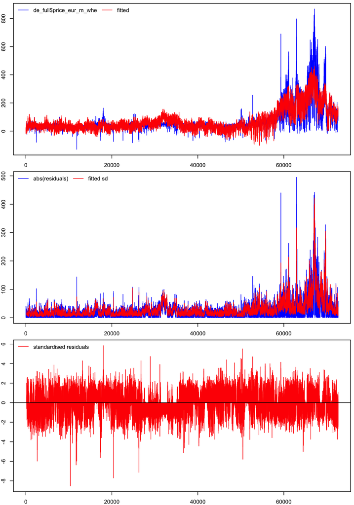

```r
rint_de_levs_sel_logewma %>% plot
```

##### Shares as Exp. Vars.

```r
reg_mat_shares <- as.matrix(select(de_full,
                                       #'shr_gen_biomass_mw',
                                       'shr_gen_gas_mw',
                                       'shr_gen_coal_mw',
                                       'shr_gen_hydro_mw',
                                       'shr_gen_geoth_mw',
                                       'shr_gen_nuclear_mw',
                                       'shr_gen_oth_ren_mw',
                                       'shr_gen_solar_mw',
                                       'shr_gen_wind_mw',
                                       'log_PNGASEU',
                                       'log_PALLFNF',
                                       'log_PINDU',
                                       contains('hour'),
                                       contains('month'),
                                       contains('weekday'),
                                       #"log_redisp_mwh",
                                       shr_net_imports)) # 'gen_wind_mw' 'gen_coal_mw', 'gen_hydro_mw',

colnames(reg_mat_shares) <- gen_var_labels(reg_mat_shares)

rint_de_mod_shares <- arx(de_full$price_eur_m_whe,
              mxreg = reg_mat_shares)

rint_de_mod_shares_logewma <- arx(de_full$price_eur_m_whe,
                     log.ewma = c(12, 24, 168),
                     mxreg = reg_mat_shares)

rint_de_shares_sel <- getsm(rint_de_mod_shares, ar.LjungB = NULL, arch.LjungB = NULL)
```

```
##
## GUM mean equation:
##
##                  reg.no. keep        coef   std.error    t-stat   p-value
## mconst                 1    0  3.3175e+02  1.1453e+01   28.9649 < 2.2e-16 ***
## Gas gen (sh)           2    0  4.9296e+02  5.2230e+00   94.3835 < 2.2e-16 ***
## Coal gen (sh)          3    0 -1.6641e+02  4.2148e+00  -39.4817 < 2.2e-16 ***
## Hydro gen (sh)         4    0 -5.7251e+01  6.9156e+00   -8.2784 < 2.2e-16 ***
## Goethermal (sh)        5    0  1.7041e+04  2.2714e+03    7.5022 6.346e-14 ***
## Nuclear (sh)           6    0 -3.3610e+02  7.0136e+00  -47.9216 < 2.2e-16 ***
## Other renew (sh)       7    0  1.0536e+04  3.4114e+02   30.8855 < 2.2e-16 ***
## Solar gen (sh)         8    0 -7.4324e+01  3.0352e+00  -24.4872 < 2.2e-16 ***
## Wind gen (sh)          9    0 -1.3653e+02  3.0988e+00  -44.0590 < 2.2e-16 ***
## Gas Price             10    0  8.8203e+01  9.7252e-01   90.6952 < 2.2e-16 ***
## Commodity Ind.        11    0  1.5410e+02  3.6462e+00   42.2627 < 2.2e-16 ***
## Indust.Inp.Ind.       12    0 -2.3661e+02  2.2752e+00 -103.9976 < 2.2e-16 ***
## Hour 01               13    0  2.3773e-01  1.0980e+00    0.2165 0.8285917
## Hour 02               14    0  8.1396e-02  1.1050e+00    0.0737 0.9412809
## Hour 03               15    0 -1.8393e+00  1.1141e+00   -1.6509 0.0987690 .
## Hour 04               16    0 -3.0621e+00  1.1211e+00   -2.7313 0.0063101 **
## Hour 05               17    0 -2.9748e+00  1.1247e+00   -2.6449 0.0081721 **
## Hour 06               18    0  1.1466e+00  1.1639e+00    0.9851 0.3245736
## Hour 07               19    0  6.6084e+00  1.2028e+00    5.4940 3.942e-08 ***
## Hour 08               20    0  5.7434e+00  1.2243e+00    4.6913 2.719e-06 ***
## Hour 09               21    0  4.6029e-01  1.2355e+00    0.3726 0.7094799
## Hour 10               22    0 -3.9860e+00  1.2638e+00   -3.1539 0.0016119 **
## Hour 11               23    0 -5.0517e+00  1.3007e+00   -3.8839 0.0001029 ***
## Hour 12               24    0 -5.6252e+00  1.3183e+00   -4.2671 1.982e-05 ***
## Hour 13               25    0 -5.3333e+00  1.3254e+00   -4.0241 5.726e-05 ***
## Hour 14               26    0 -3.4516e+00  1.3181e+00   -2.6187 0.0088291 **
## Hour 15               27    0  2.3020e-01  1.2999e+00    0.1771 0.8594409
## Hour 16               28    0  4.3002e+00  1.2756e+00    3.3711 0.0007492 ***
## Hour 17               29    0  1.2419e+01  1.2602e+00    9.8553 < 2.2e-16 ***
## Hour 18               30    0  1.7221e+01  1.2378e+00   13.9122 < 2.2e-16 ***
## Hour 19               31    0  1.7814e+01  1.2082e+00   14.7438 < 2.2e-16 ***
## Hour 20               32    0  1.1877e+01  1.1691e+00   10.1589 < 2.2e-16 ***
## Hour 21               33    0  4.7904e+00  1.1418e+00    4.1953 2.729e-05 ***
## Hour 22               34    0  2.5310e+00  1.1229e+00    2.2539 0.0242036 *
## Hour 23               35    0 -1.5161e+00  1.1014e+00   -1.3765 0.1686770
## February              36    0  4.6964e+00  7.6126e-01    6.1693 6.894e-10 ***
```

[output cut: 11 more lines]

```
## Saturday              48    0 -3.1186e+00  6.1901e-01   -5.0381 4.713e-07 ***
## Sunday                49    0 -5.9854e+00  6.6178e-01   -9.0443 < 2.2e-16 ***
## Thursday              50    0  1.9480e+00  5.9219e-01    3.2894 0.0010044 **
## Tuesday               51    0  3.3370e+00  5.9336e-01    5.6238 1.874e-08 ***
## Wednesday             52    0  2.3166e+00  5.9347e-01    3.9035 9.488e-05 ***
## Net Imprts (sh)       53    0  5.1465e+00  4.0355e+00    1.2753 0.2022063
## ---
## Signif. codes:  0 '***' 0.001 '**' 0.01 '*' 0.05 '.' 0.1 ' ' 1
##
##
## Diagnostics:
##
##                   Chi-sq df p-value
## Ljung-Box AR(1)    67927  1       0
## Ljung-Box ARCH(1)  63936  1       0
```

```
## 8 path(s) to search
```

```
## Searching: 1 2 3 4 5 6 7 8
```

```
##
##   Path 1: 13 14 27 21 18 53
##   Path 2: 14 27 13 21 18 53
##   Path 3: 15 35 27 21 53 14 13 18
##   Path 4: 18 21 13 27 14 53
##   Path 5: 21 27 13 14 18 53
##   Path 6: 27 14 13 21 18 53
##   Path 7: 35 14 27 13 21 53 18
##   Path 8: 53 14 27 21 13 18
##
## Terminal models:
##
##                 info(sc)      logl     n  k
## spec 1 (1-cut): 10.34871 -375608.0 72639 45
## spec 2:         10.34889 -375603.5 72639 47
## spec 3:         10.34880 -375605.7 72639 46
##
## Retained regressors (final model):
##
##   mconst   Gas gen (sh)   Coal gen (sh)   Hydro gen (sh)   Goethermal (sh)   Nuclear (sh)   Other renew (sh)   Solar gen (sh)   Wind gen (sh)   Gas Price   Commodity Ind.   Indust.Inp.Ind.   Hour 04   Hour 05   Hour 07   Hour 08   Hour 10   Hour 11   Hour 12   Hour 13   Hour 14   Hour 16   Hour 1…
```

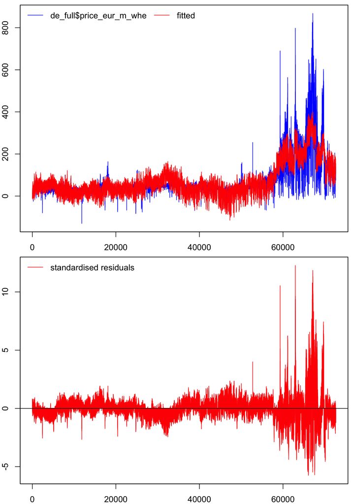

```r
rint_de_shares_sel %>% plot
```

```r
rint_de_shares_sel_logewma <- getsm(rint_de_mod_shares_logewma, ar.LjungB = NULL, arch.LjungB = NULL)
```

```
##
## GUM mean equation:
##
##                  reg.no. keep        coef   std.error    t-stat   p-value
## mconst                 1    0  3.3175e+02  1.1453e+01   28.9649 < 2.2e-16 ***
## Gas gen (sh)           2    0  4.9296e+02  5.2230e+00   94.3835 < 2.2e-16 ***
## Coal gen (sh)          3    0 -1.6641e+02  4.2148e+00  -39.4817 < 2.2e-16 ***
## Hydro gen (sh)         4    0 -5.7251e+01  6.9156e+00   -8.2784 < 2.2e-16 ***
## Goethermal (sh)        5    0  1.7041e+04  2.2714e+03    7.5022 6.346e-14 ***
## Nuclear (sh)           6    0 -3.3610e+02  7.0136e+00  -47.9216 < 2.2e-16 ***
## Other renew (sh)       7    0  1.0536e+04  3.4114e+02   30.8855 < 2.2e-16 ***
## Solar gen (sh)         8    0 -7.4324e+01  3.0352e+00  -24.4872 < 2.2e-16 ***
## Wind gen (sh)          9    0 -1.3653e+02  3.0988e+00  -44.0590 < 2.2e-16 ***
## Gas Price             10    0  8.8203e+01  9.7252e-01   90.6952 < 2.2e-16 ***
## Commodity Ind.        11    0  1.5410e+02  3.6462e+00   42.2627 < 2.2e-16 ***
## Indust.Inp.Ind.       12    0 -2.3661e+02  2.2752e+00 -103.9976 < 2.2e-16 ***
## Hour 01               13    0  2.3773e-01  1.0980e+00    0.2165 0.8285917
## Hour 02               14    0  8.1396e-02  1.1050e+00    0.0737 0.9412809
## Hour 03               15    0 -1.8393e+00  1.1141e+00   -1.6509 0.0987690 .
## Hour 04               16    0 -3.0621e+00  1.1211e+00   -2.7313 0.0063101 **
## Hour 05               17    0 -2.9748e+00  1.1247e+00   -2.6449 0.0081721 **
## Hour 06               18    0  1.1466e+00  1.1639e+00    0.9851 0.3245736
## Hour 07               19    0  6.6084e+00  1.2028e+00    5.4940 3.942e-08 ***
## Hour 08               20    0  5.7434e+00  1.2243e+00    4.6913 2.719e-06 ***
## Hour 09               21    0  4.6029e-01  1.2355e+00    0.3726 0.7094799
## Hour 10               22    0 -3.9860e+00  1.2638e+00   -3.1539 0.0016119 **
## Hour 11               23    0 -5.0517e+00  1.3007e+00   -3.8839 0.0001029 ***
## Hour 12               24    0 -5.6252e+00  1.3183e+00   -4.2671 1.982e-05 ***
## Hour 13               25    0 -5.3333e+00  1.3254e+00   -4.0241 5.726e-05 ***
## Hour 14               26    0 -3.4516e+00  1.3181e+00   -2.6187 0.0088291 **
## Hour 15               27    0  2.3020e-01  1.2999e+00    0.1771 0.8594409
## Hour 16               28    0  4.3002e+00  1.2756e+00    3.3711 0.0007492 ***
## Hour 17               29    0  1.2419e+01  1.2602e+00    9.8553 < 2.2e-16 ***
## Hour 18               30    0  1.7221e+01  1.2378e+00   13.9122 < 2.2e-16 ***
## Hour 19               31    0  1.7814e+01  1.2082e+00   14.7438 < 2.2e-16 ***
## Hour 20               32    0  1.1877e+01  1.1691e+00   10.1589 < 2.2e-16 ***
## Hour 21               33    0  4.7904e+00  1.1418e+00    4.1953 2.729e-05 ***
## Hour 22               34    0  2.5310e+00  1.1229e+00    2.2539 0.0242036 *
## Hour 23               35    0 -1.5161e+00  1.1014e+00   -1.3765 0.1686770
## February              36    0  4.6964e+00  7.6126e-01    6.1693 6.894e-10 ***
```

[output cut: 20 more lines]

```
## GUM log-variance equation:
##
##                    coef std.error  t-stat   p-value
## vconst        -0.135025  0.041364 10.6558  0.001097 **
## logEqWMA(12)   0.716426  0.012297 58.2597 < 2.2e-16 ***
## logEqWMA(24)   0.303024  0.015492 19.5604 < 2.2e-16 ***
## logEqWMA(168)  0.033209  0.010462  3.1742  0.001503 **
## ---
## Signif. codes:  0 '***' 0.001 '**' 0.01 '*' 0.05 '.' 0.1 ' ' 1
##
## Diagnostics:
##
##                   Chi-sq df p-value
## Ljung-Box AR(1)    62373  1       0
## Ljung-Box ARCH(1)  34072  1       0
```

```
## 8 path(s) to search
## Searching: 1 2 3 4 5 6 7 8
```

```
##
##   Path 1: 13 14 27 21 18 53
##   Path 2: 14 27 13 21 18 53
##   Path 3: 15 35 27 21 53 14 13 18
##   Path 4: 18 21 13 27 14 53
##   Path 5: 21 27 13 14 18 53
##   Path 6: 27 14 13 21 18 53
##   Path 7: 35 14 27 13 21 53 18
##   Path 8: 53 14 27 21 13 18
##
## Terminal models:
##
##                 info(sc)      logl     n  k
## spec 1 (1-cut): 9.256344 -335933.9 72639 45
## spec 2:         9.256699 -335935.6 72639 47
## spec 3:         9.256848 -335946.6 72639 46
##
## Retained regressors (final model):
##
##   mconst   Gas gen (sh)   Coal gen (sh)   Hydro gen (sh)   Goethermal (sh)   Nuclear (sh)   Other renew (sh)   Solar gen (sh)   Wind gen (sh)   Gas Price   Commodity Ind.   Indust.Inp.Ind.   Hour 04   Hour 05   Hour 07   Hour 08   Hour 10   Hour 11   Hour 12   Hour 13   Hour 14   Hour 16   Hour 1…
```

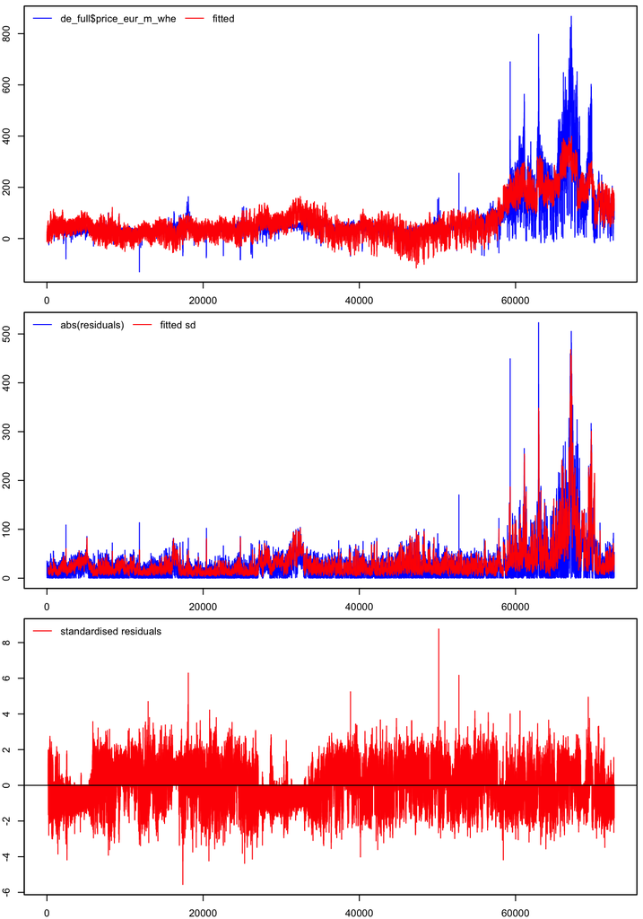

```r
rint_de_shares_sel_logewma %>% plot
```

#### ARCH (Escribano et al. 2018)

In this one, I get as close with built-in gets functionality to replicating Escribano & Sucarrat 2018 in which they incorporate GARCH(1,1), with periodic dummies, asymmetric leverage term, and correlated volatilities (? not sure if this is the right phrasing). I do not include their described “volatility feedback” parameters in the log-variance equation, as we do not estimate the model as individual hourly series but rather as a sequential hourly time series.

The below looks again at explanatory variables for fuel sources as levels OR shares. Each mean model incorporates AR(7) terms, hourly and monthly dummies. The volatility models incorporate log-ARCH(1) errors, hourly and monthly dummies, and an asymmetric leverage term.

I believe the below is the correct notation now, where W represents the wholesale hourly electricity price. First, the mean model:

$$\begin{align}
W_{h,t} = \; & \alpha
+ \underbrace{\sum_{k=1}^{7} \phi_k W_{h,t-k}}_{\text{AR(7)}}
+ \underbrace{\sum_{j \in \mathcal{J}} \beta_j
x_{j,h,t}}_{\text{fundamentals (levels or shares)}}
& + \underbrace{\sum_{d=2}^{7} \gamma_d D_{d,t}
+ \sum_{s=2}^{12} \psi_s M_{s,t}}_{\text{hour & month dummies}}
+ \varepsilon_{h,t}
\end{align}$$

where $x_{j,h,t}$ is either $ln X_{j,h,t}$ (Model 1 — log-levels) or $s_{j,h,t}=\frac{X_{j,h,t}}{Load_{h,t}}$ (Model 2 — shares).

Second, the model of the log-variance:

$$\begin{align}
\ln \sigma^2_{h,t} = \; & \omega
+ \underbrace{\alpha \ln \varepsilon^2_{h,t-1}}_{\text{log-ARCH(1)}}
+ \underbrace{\delta \cdot \mathbf{1}(\varepsilon_{h,t-1} < 0) \cdot
\ln \varepsilon^2_{h,t-1}}_{\text{asymmetric leverage term}} \nonumber
\\
& + \underbrace{\sum_{d=2}^{7} \lambda_d D_{d,t}
+ \sum_{s=2}^{12} \mu_s M_{s,t}}_{\text{hour & month dummies in
variance}}
\end{align}$$

where $1(\varepsilon_{h,t−1}<0)$ is an indicator function equal to 1 when the lagged error is negative. A significant $\delta$ indicates that negative shocks to price have a different effect on subsequent volatility than positive shocks of the same size.

##### Levels as Exp. Vars.

###### w.o. Indicators

```r
var_mat <- as.matrix(select(de_full, contains('hour'),
                                       contains('month')))

esc_de_mod_levs_arch <- arx(de_full$price_eur_m_whe,
              ar = 1:7,
              asym = 1,
              arch = 1,
              mxreg = lev_reg_mat,
              vxreg = var_mat)

# model selection and plotting of residuals
esc_de_levs_sel <- getsm(esc_de_mod_levs_arch, ar.LjungB = NULL, arch.LjungB = NULL)
```

```
##
## GUM mean equation:
##
##                 reg.no. keep        coef   std.error   t-stat   p-value
## mconst                1    0  1.8908e+01  5.6451e+00   3.3494 0.0008102 ***
## ar1                   2    0  1.4307e+00  3.7143e-03 385.1813 < 2.2e-16 ***
## ar2                   3    0 -4.2421e-01  6.4843e-03 -65.4203 < 2.2e-16 ***
## ar3                   4    0 -1.5811e-01  6.6705e-03 -23.7032 < 2.2e-16 ***
## ar4                   5    0  4.8358e-02  6.6927e-03   7.2255 5.042e-13 ***
## ar5                   6    0  2.1660e-02  6.6683e-03   3.2481 0.0011621 **
## ar6                   7    0 -8.0712e-02  6.4748e-03 -12.4656 < 2.2e-16 ***
## ar7                   8    0  1.2599e-01  3.6562e-03  34.4598 < 2.2e-16 ***
## Load                  9    0  1.3072e+00  5.1247e-01   2.5509 0.0107480 *
## Gas gen.             10    0  3.2096e-01  9.8042e-02   3.2737 0.0010619 **
## Coal gen.            11    0 -6.0425e-01  1.5841e-01  -3.8144 0.0001367 ***
## Hydro gen.           12    0 -1.4008e+00  1.1291e-01 -12.4064 < 2.2e-16 ***
## Geothermal gen.      13    0  1.6694e-02  1.6726e-01   0.0998 0.9204967
## Nuclear gen.         14    0 -8.0174e-01  1.5873e-01  -5.0511 4.403e-07 ***
## Other renewbls       15    0  1.0074e+00  1.7930e-01   5.6186 1.932e-08 ***
## Solar gen.           16    0  4.4590e-01  2.0536e-02  21.7126 < 2.2e-16 ***
## Wind gen.            17    0  3.8843e-02  5.7792e-02   0.6721 0.5015094
## Gas Price            18    0  2.5304e+00  2.2798e-01  11.0996 < 2.2e-16 ***
## Commodity Ind.       19    0  4.7597e+00  8.1704e-01   5.8255 5.717e-09 ***
## Indust.Inp.Ind.      20    0 -8.5122e+00  5.1679e-01 -16.4713 < 2.2e-16 ***
## Hour 01              21    0 -3.0891e+00  2.2915e-01 -13.4808 < 2.2e-16 ***
## Hour 02              22    0 -2.6799e+00  2.3195e-01 -11.5536 < 2.2e-16 ***
## Hour 03              23    0 -2.3931e+00  2.3432e-01 -10.2126 < 2.2e-16 ***
## Hour 04              24    0 -1.9197e-02  2.3554e-01  -0.0815 0.9350418
## Hour 05              25    0  2.1731e+00  2.3663e-01   9.1836 < 2.2e-16 ***
## Hour 06              26    0  8.0376e+00  2.3993e-01  33.4999 < 2.2e-16 ***
## Hour 07              27    0  3.7792e+00  2.5306e-01  14.9340 < 2.2e-16 ***
## Hour 08              28    0 -5.0576e+00  2.7133e-01 -18.6401 < 2.2e-16 ***
## Hour 09              29    0 -8.4141e+00  2.9935e-01 -28.1081 < 2.2e-16 ***
## Hour 10              30    0 -5.0255e+00  3.2178e-01 -15.6179 < 2.2e-16 ***
## Hour 11              31    0 -2.6980e+00  3.3358e-01  -8.0880 6.159e-16 ***
## Hour 12              32    0 -5.8079e+00  3.3262e-01 -17.4610 < 2.2e-16 ***
## Hour 13              33    0 -5.4980e+00  3.2867e-01 -16.7282 < 2.2e-16 ***
## Hour 14              34    0 -4.1770e+00  3.2434e-01 -12.8783 < 2.2e-16 ***
## Hour 15              35    0 -2.5517e+00  3.1993e-01  -7.9760 1.533e-15 ***
## Hour 16              36    0 -2.1575e+00  3.1292e-01  -6.8947 5.440e-12 ***
```

[output cut: 71 more lines]

```
## month_6  -0.3118159  0.0435887   -7.1536 8.533e-13 ***
## month_7  -0.2094002  0.0431947   -4.8478 1.251e-06 ***
## month_8  -0.1513237  0.0431941   -3.5033 0.0004597 ***
## month_9  -0.0499498  0.0435633   -1.1466 0.2515497
## month_10  0.2064876  0.0431799    4.7820 1.739e-06 ***
## month_11  0.1832456  0.0435719    4.2056 2.607e-05 ***
## month_12  0.2364650  0.0431974    5.4741 4.413e-08 ***
## ---
## Signif. codes:  0 '***' 0.001 '**' 0.01 '*' 0.05 '.' 0.1 ' ' 1
##
## Diagnostics:
##
##                   Chi-sq df p-value
## Ljung-Box AR(8)   1134.1  8       0
## Ljung-Box ARCH(2) 1269.4  2       0
```

```
## 14 path(s) to search
```

```
## Searching: 1 2 3 4 5 6 7 8 9 10 11 12 13 14
```

```
##
##   Path 1: 13 24 60 63 17 58 44 42 59 57 61 53 50 51
##   Path 2: 17 24 13 63 60 58 44 42 59 57 61 53 50 51
##   Path 3: 24 13 60 63 17 58 44 42 59 57 61 53 50 51
##   Path 4: 42 13 60 63 24 17 58 44 59 57 61 53 50 51
##   Path 5: 44 13 24 63 60 17 58 42 59 57 61 53 50 51
##   Path 6: 50 24 60 13 44 58 63 17 53 42 51 59 61 57
##   Path 7: 53 13 24 44 60 63 17 58 42 50 51 59 61 57
##   Path 8: 56 24 13 63 17 42 60 44 58 50 53 51 61 59
##   Path 9: 57 13 60 24 58 63 17 59 44 61 42 53 50 51
##   Path 10: 58 60 24 13 63 17 44 42 59 57 61 53 50 51
##   Path 11: 59 13 24 58 60 63 17 44 57 61 42 53 50 51
##   Path 12: 60 24 13 63 17 58 44 42 59 57 61 53 50 51
##   Path 13: 61 13 24 63 60 17 58 44 42 59 57 53 50 51
##   Path 14: 63 24 13 60 17 58 44 42 59 57 61 53 50 51
##
## Terminal models:
##
##         info(sc)      logl     n  k
## spec 1: 6.569234 -238249.3 72632 57
## spec 2: 6.596802 -239250.5 72632 57
##
## Retained regressors (final model):
##
##   mconst   ar1   ar2   ar3   ar4   ar5   ar6   ar7   Load   Gas gen.   Coal gen.   Hydro gen.   Nuclear gen.   Other renewbls   Solar gen.   Gas Price   Commodity Ind.   Indust.Inp.Ind.   Hour 01   Hour 02   Hour 03   Hour 05   Hour 06   Hour 07   Hour 08   Hour 09   Hour 10   Hour 11   Hour 12  …
##
## Messages:
##
## - 1-CUT excluded from terminals, since it does not pass the PET
```

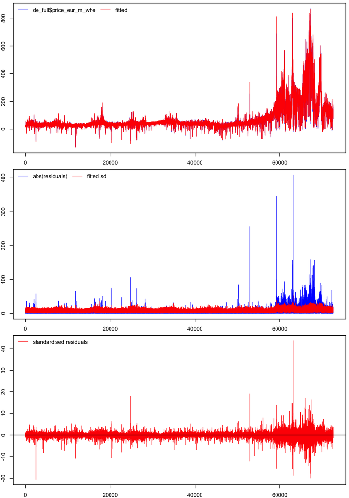

```r
esc_de_levs_sel %>% plot
```

###### w. Indicators

```r
lev_reg_mat_inds <- as.matrix(select(de_full,
                                       'log_load',
                                       #'log_gen_biomass_mw',
                                       'log_gen_gas_mw',
                                       'log_gen_coal_mw',
                                       'log_gen_hydro_mw',
                                       'log_gen_geoth_mw',
                                       'log_gen_nuclear_mw',
                                       'log_gen_oth_ren_mw',
                                       'log_gen_solar_mw',
                                       'log_gen_wind_mw',
                                       'log_PNGASEU',
                                       'log_PALLFNF',
                                       'log_PINDU',
                                       contains('hour'),
                                       contains('month'),
                                       contains('weekday'),
                                       "net_imports_SE",
                                       "net_imports_PL",
                                       "net_imports_CZ",
                                       "net_imports_BE",
                                       "net_imports_CH",
                                       "net_imports_NO",
                                       "net_imports_NL",
                                       "net_imports_LU",
                                       "net_imports_FR",
                                       "net_imports_DK",
                                       "net_imports_AT",
                                "covid_ind",
                                "ukraine_ind"
                                #"iran_ind"
                                       #"log_redisp_mwh"
                                       #"total_net_imports" # Excluded as its sum components are each of the net_imports above
                                       )) # 'gen_wind_mw' 'gen_coal_mw', 'gen_hydro_mw',

colnames(lev_reg_mat_inds) <- gen_var_labels(lev_reg_mat_inds)


var_mat_inds <- as.matrix(select(de_full, "covid_ind", "ukraine_ind", #"iran_ind",
                            contains('hour'),
                                       contains('month')))

esc_de_mod_levs_arch_inds <- arx(de_full$price_eur_m_whe,
              ar = 1:7,
              asym = 1,
              arch = 1,
              mxreg = lev_reg_mat_inds,
              vxreg = var_mat_inds)

# model selection and plotting of residuals
esc_de_levs_sel_inds <- getsm(esc_de_mod_levs_arch_inds, ar.LjungB = NULL, arch.LjungB = NULL)
```

```
##
## GUM mean equation:
##
##                 reg.no. keep        coef   std.error   t-stat   p-value
## mconst                1    0  7.7231e+00  5.9193e+00   1.3047 0.1919888
## ar1                   2    0  1.4295e+00  3.7163e-03 384.6628 < 2.2e-16 ***
## ar2                   3    0 -4.2393e-01  6.4821e-03 -65.3997 < 2.2e-16 ***
## ar3                   4    0 -1.5810e-01  6.6680e-03 -23.7102 < 2.2e-16 ***
## ar4                   5    0  4.8173e-02  6.6902e-03   7.2005 6.056e-13 ***
## ar5                   6    0  2.1569e-02  6.6659e-03   3.2357 0.0012139 **
## ar6                   7    0 -8.0610e-02  6.4725e-03 -12.4542 < 2.2e-16 ***
## ar7                   8    0  1.2540e-01  3.6559e-03  34.3023 < 2.2e-16 ***
## Load                  9    0  1.6924e+00  5.1750e-01   3.2703 0.0010749 **
## Gas gen.             10    0  2.7991e-01  1.0042e-01   2.7874 0.0053152 **
## Coal gen.            11    0 -4.2236e-01  1.6452e-01  -2.5673 0.0102518 *
## Hydro gen.           12    0 -1.4134e+00  1.1290e-01 -12.5186 < 2.2e-16 ***
## Geothermal gen.      13    0 -7.7731e-02  1.6774e-01  -0.4634 0.6430774
## Nuclear gen.         14    0 -1.0565e-01  2.0393e-01  -0.5181 0.6043954
## Other renewbls       15    0  1.1893e+00  1.8448e-01   6.4471 1.147e-10 ***
## Solar gen.           16    0  4.4145e-01  2.0543e-02  21.4896 < 2.2e-16 ***
## Wind gen.            17    0  6.0145e-02  5.7847e-02   1.0397 0.2984732
## Gas Price            18    0  2.1535e+00  2.4345e-01   8.8456 < 2.2e-16 ***
## Commodity Ind.       19    0  6.6716e+00  9.6515e-01   6.9125 4.800e-12 ***
## Indust.Inp.Ind.      20    0 -1.0598e+01  6.7997e-01 -15.5862 < 2.2e-16 ***
## Hour 01              21    0 -3.0659e+00  2.2909e-01 -13.3828 < 2.2e-16 ***
## Hour 02              22    0 -2.6495e+00  2.3193e-01 -11.4240 < 2.2e-16 ***
## Hour 03              23    0 -2.3683e+00  2.3429e-01 -10.1083 < 2.2e-16 ***
## Hour 04              24    0 -1.6609e-02  2.3547e-01  -0.0705 0.9437657
## Hour 05              25    0  2.1529e+00  2.3656e-01   9.1008 < 2.2e-16 ***
## Hour 06              26    0  7.9825e+00  2.4000e-01  33.2597 < 2.2e-16 ***
## Hour 07              27    0  3.7166e+00  2.5334e-01  14.6704 < 2.2e-16 ***
## Hour 08              28    0 -5.1294e+00  2.7188e-01 -18.8662 < 2.2e-16 ***
## Hour 09              29    0 -8.4920e+00  2.9999e-01 -28.3080 < 2.2e-16 ***
## Hour 10              30    0 -5.1150e+00  3.2246e-01 -15.8621 < 2.2e-16 ***
## Hour 11              31    0 -2.7982e+00  3.3428e-01  -8.3708 < 2.2e-16 ***
## Hour 12              32    0 -5.9002e+00  3.3319e-01 -17.7082 < 2.2e-16 ***
## Hour 13              33    0 -5.5717e+00  3.2910e-01 -16.9302 < 2.2e-16 ***
## Hour 14              34    0 -4.2425e+00  3.2471e-01 -13.0656 < 2.2e-16 ***
## Hour 15              35    0 -2.6115e+00  3.2024e-01  -8.1548 3.554e-16 ***
## Hour 16              36    0 -2.2199e+00  3.1326e-01  -7.0865 1.388e-12 ***
```

[output cut: 75 more lines]

```
## month_6     -0.3793447  0.0414194   -9.1586 < 2.2e-16 ***
## month_7     -0.2758958  0.0410433   -6.7221 1.805e-11 ***
## month_8     -0.2173540  0.0410434   -5.2957 1.189e-07 ***
## month_9     -0.0878976  0.0413891   -2.1237 0.0336992 *
## month_10     0.2067059  0.0410225    5.0388 4.695e-07 ***
## month_11     0.1657026  0.0413932    4.0031 6.257e-05 ***
## month_12     0.2328276  0.0410384    5.6734 1.405e-08 ***
## ---
## Signif. codes:  0 '***' 0.001 '**' 0.01 '*' 0.05 '.' 0.1 ' ' 1
##
## Diagnostics:
##
##                   Chi-sq df p-value
## Ljung-Box AR(8)   1245.8  8       0
## Ljung-Box ARCH(2) 5365.5  2       0
```

```
## 14 path(s) to search
```

```
## Searching: 1 2 3 4 5 6 7 8 9 10 11 12 13 14
```

```
##
##   Path 1: 1 24 14 60 13 58 42 63 17 56 44 50 59 51 61 53
##   Path 2: 13 24 60 63 14 58 42 17 1 56 44 50 59 51 61 53
##   Path 3: 14 24 60 63 13 58 42 17 1 56 44 50 59 51 61 53
##   Path 4: 17 24 63 60 13 58 14 42 1 56 44 50 59 51 61 53
##   Path 5: 24 60 63 14 13 58 42 17 1 56 44 50 59 51 61 53
##   Path 6: 42 60 63 24 13 14 58 17 1 56 44 50 59 51 61 53
##   Path 7: 44 24 60 63 14 13 58 42 17 1 56 50 59 51 61 53
##   Path 8: 50 13 24 60 58 14 1 42 63 44 56 17 59 51 61 53
##   Path 9: 56 24 13 63 14 42 60 1 58 17 44 50 59 51 61 53
##   Path 10: 58 60 24 63 14 13 42 17 1 56 44 50 59 51 61 53
##   Path 11: 59 58 24 63 60 14 13 42 17 1 56 44 50 51 61 53
##   Path 12: 60 24 63 14 13 58 42 17 1 56 44 50 59 51 61 53
##   Path 13: 61 24 60 63 13 58 14 42 17 1 56 44 50 59 51 53
##   Path 14: 63 24 60 14 13 58 42 17 1 56 44 50 59 51 61 53
##
## Terminal models:
##
##                 info(sc)      logl     n  k
## spec 1 (1-cut): 6.124475 -222086.2 72632 59
## spec 2:         6.123616 -222066.2 72632 57
##
## Retained regressors (final model):
##
##   ar1   ar2   ar3   ar4   ar5   ar6   ar7   Load   Gas gen.   Coal gen.   Hydro gen.   Other renewbls   Solar gen.   Gas Price   Commodity Ind.   Indust.Inp.Ind.   Hour 01   Hour 02   Hour 03   Hour 05   Hour 06   Hour 07   Hour 08   Hour 09   Hour 10   Hour 11   Hour 12   Hour 13   Hour 14   Hou…
```

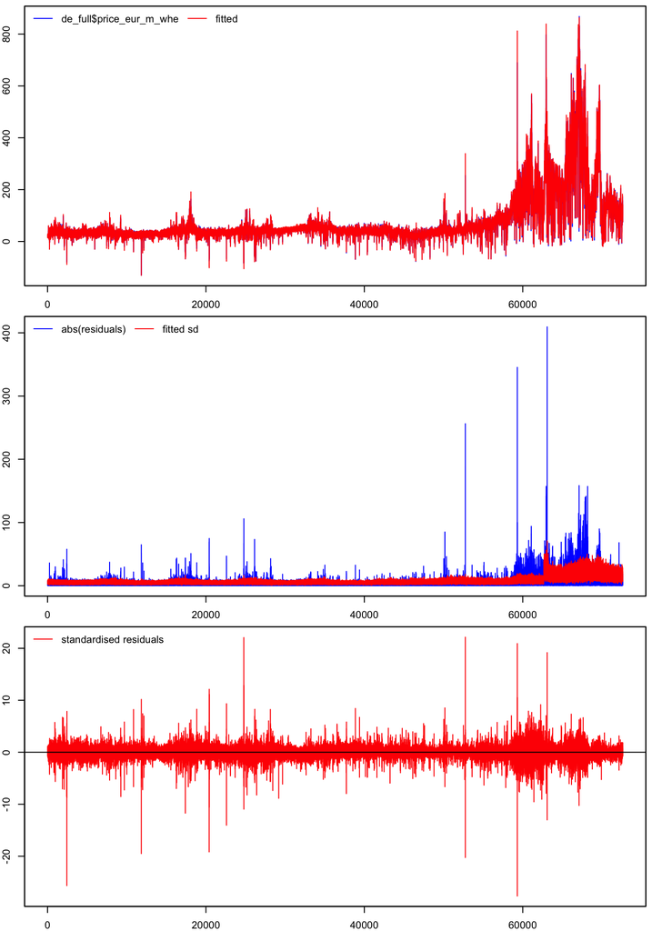

```r
esc_de_levs_sel_inds %>% plot
```

##### Shares as Exp. Vars.

###### w.o. Indicators

```r
esc_de_mod_shares_arch <- arx(de_full$price_eur_m_whe,
              # Question: In theory, the ARCH(24) would proxy the seasonal (daily) AR term?
              #arch = 1:24,
              ar = 1:7,
              asym = 1,
              arch = 1,
              mxreg = reg_mat_shares,
              vxreg = var_mat)

# model selection and plotting of residuals
esc_de_shares_sel <- getsm(esc_de_mod_shares_arch, ar.LjungB = NULL, arch.LjungB = NULL)
```

```
##
## GUM mean equation:
##
##                  reg.no. keep        coef   std.error   t-stat   p-value
## mconst                 1    0 -2.7633e+00  2.3702e+00  -1.1658 0.2436867
## ar1                    2    0  1.4496e+00  3.6811e-03 393.8032 < 2.2e-16 ***
## ar2                    3    0 -4.2715e-01  6.5152e-03 -65.5612 < 2.2e-16 ***
## ar3                    4    0 -1.6035e-01  6.7001e-03 -23.9322 < 2.2e-16 ***
## ar4                    5    0  4.8211e-02  6.7235e-03   7.1705 7.542e-13 ***
## ar5                    6    0  2.2339e-02  6.6992e-03   3.3346 0.0008547 ***
## ar6                    7    0 -7.9421e-02  6.5047e-03 -12.2097 < 2.2e-16 ***
## ar7                    8    0  1.2035e-01  3.6807e-03  32.6970 < 2.2e-16 ***
## Gas gen (sh)           9    0  9.3748e+00  1.1478e+00   8.1675 3.200e-16 ***
## Coal gen (sh)         10    0  7.4817e+00  8.8033e-01   8.4987 < 2.2e-16 ***
## Hydro gen (sh)        11    0 -1.9213e+01  1.4351e+00 -13.3879 < 2.2e-16 ***
## Goethermal (sh)       12    0 -2.4325e+03  4.6949e+02  -5.1811 2.211e-07 ***
## Nuclear (sh)          13    0 -3.7465e-01  1.4671e+00  -0.2554 0.7984356
## Other renew (sh)      14    0  3.6315e+02  7.0447e+01   5.1550 2.543e-07 ***
## Solar gen (sh)        15    0  1.5608e+01  6.4607e-01  24.1586 < 2.2e-16 ***
## Wind gen (sh)         16    0  6.9147e+00  6.4940e-01  10.6479 < 2.2e-16 ***
## Gas Price             17    0  9.4914e-01  2.1295e-01   4.4570 8.322e-06 ***
## Commodity Ind.        18    0  7.4873e+00  7.5701e-01   9.8906 < 2.2e-16 ***
## Indust.Inp.Ind.       19    0 -7.3371e+00  5.0391e-01 -14.5603 < 2.2e-16 ***
## Hour 01               20    0 -3.0795e+00  2.2969e-01 -13.4070 < 2.2e-16 ***
## Hour 02               21    0 -2.5829e+00  2.3202e-01 -11.1320 < 2.2e-16 ***
## Hour 03               22    0 -2.2907e+00  2.3441e-01  -9.7719 < 2.2e-16 ***
## Hour 04               23    0 -3.0335e-02  2.3552e-01  -0.1288 0.8975161
## Hour 05               24    0  2.2002e+00  2.3763e-01   9.2590 < 2.2e-16 ***
## Hour 06               25    0  8.4132e+00  2.4479e-01  34.3692 < 2.2e-16 ***
## Hour 07               26    0  4.8010e+00  2.5583e-01  18.7662 < 2.2e-16 ***
## Hour 08               27    0 -3.1185e+00  2.5926e-01 -12.0283 < 2.2e-16 ***
## Hour 09               28    0 -5.6183e+00  2.6139e-01 -21.4936 < 2.2e-16 ***
## Hour 10               29    0 -2.0922e+00  2.6926e-01  -7.7701 7.946e-15 ***
## Hour 11               30    0 -1.2950e-01  2.7564e-01  -0.4698 0.6384717
## Hour 12               31    0 -3.7450e+00  2.7499e-01 -13.6188 < 2.2e-16 ***
## Hour 13               32    0 -3.6765e+00  2.7385e-01 -13.4253 < 2.2e-16 ***
## Hour 14               33    0 -2.5845e+00  2.7299e-01  -9.4673 < 2.2e-16 ***
## Hour 15               34    0 -9.9285e-01  2.7055e-01  -3.6697 0.0002430 ***
## Hour 16               35    0 -6.3496e-01  2.6569e-01  -2.3899 0.0168563 *
## Hour 17               36    0  5.2491e+00  2.6279e-01  19.9744 < 2.2e-16 ***
```

[output cut: 60 more lines]

```
## month_6  -0.27609413  0.04346171   -6.3526 2.130e-10 ***
## month_7  -0.16907907  0.04307046   -3.9256 8.658e-05 ***
## month_8  -0.04484358  0.04306627   -1.0413 0.2977541
## month_9   0.04620153  0.04344147    1.0635 0.2875429
## month_10  0.13603675  0.04305327    3.1597 0.0015798 **
## month_11  0.17994558  0.04344955    4.1415 3.455e-05 ***
## month_12  0.26902240  0.04308162    6.2445 4.276e-10 ***
## ---
## Signif. codes:  0 '***' 0.001 '**' 0.01 '*' 0.05 '.' 0.1 ' ' 1
##
## Diagnostics:
##
##                   Chi-sq df p-value
## Ljung-Box AR(8)   1030.9  8       0
## Ljung-Box ARCH(2) 2156.8  2       0
```

```
## 11 path(s) to search
```

```
## Searching: 1 2 3 4 5 6 7 8 9 10 11
```

```
##
##   Path 1: 1 55 23 59 37 30 57 13 43 52 44
##   Path 2: 13 55 23 59 37 30 57 43 52 1 44
##   Path 3: 23 55 13 59 37 30 57 43 52 1 44
##   Path 4: 30 23 13 55 37 59 57 43 52 1 44
##   Path 5: 37 23 55 13 30 59 57 43 52 1 44
##   Path 6: 43 55 23 13 59 37 30 52 57 1 44
##   Path 7: 52 55 23 59 13 37 30 43 57 1 44
##   Path 8: 55 23 13 59 37 30 57 43 52 1 44
##   Path 9: 57 59 23 13 37 30 55 43 52 1 44
##   Path 10: 58 23 13 57 37 30 59 43 52 55 1 44
##   Path 11: 59 23 55 13 37 30 57 43 52 1 44
##
## Terminal models:
##
##                 info(sc)      logl     n  k
## spec 1 (1-cut): 6.549076 -237562.0 72632 49
## spec 2:         6.558775 -237914.2 72632 49
## spec 3:         6.554169 -237752.6 72632 48
##
## Retained regressors (final model):
##
##   ar1   ar2   ar3   ar4   ar5   ar6   ar7   Gas gen (sh)   Coal gen (sh)   Hydro gen (sh)   Goethermal (sh)   Other renew (sh)   Solar gen (sh)   Wind gen (sh)   Gas Price   Commodity Ind.   Indust.Inp.Ind.   Hour 01   Hour 02   Hour 03   Hour 05   Hour 06   Hour 07   Hour 08   Hour 09   Hour 10 …
```

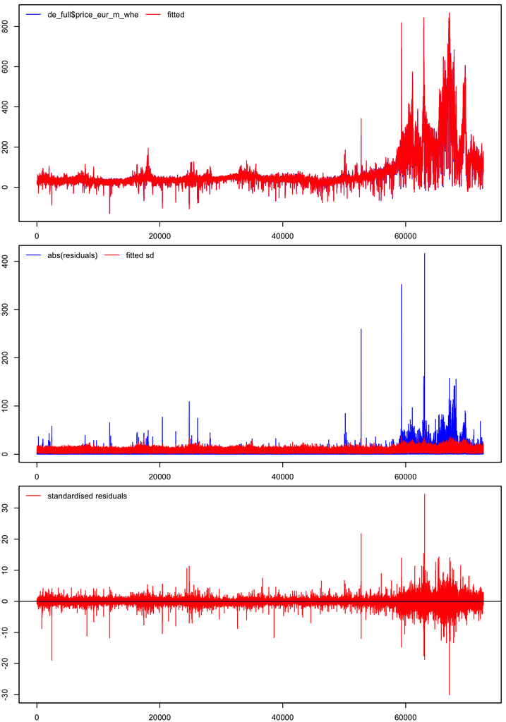

```r
esc_de_shares_sel %>% plot
```

###### w. Indicators

```r
reg_mat_shares_inds <- as.matrix(select(de_full,
                                       #'shr_gen_biomass_mw',
                                       'shr_gen_gas_mw',
                                       'shr_gen_coal_mw',
                                       'shr_gen_hydro_mw',
                                       'shr_gen_geoth_mw',
                                       'shr_gen_nuclear_mw',
                                       'shr_gen_oth_ren_mw',
                                       'shr_gen_solar_mw',
                                       'shr_gen_wind_mw',
                                       'log_PNGASEU',
                                       'log_PALLFNF',
                                       'log_PINDU',
                                       contains('hour'),
                                       contains('month'),
                                       contains('weekday'),
                                       #"log_redisp_mwh",
                                       shr_net_imports,
                                       covid_ind,
                                       ukraine_ind))
                                       #iran_ind))

colnames(reg_mat_shares_inds) <- gen_var_labels(reg_mat_shares_inds)

esc_de_mod_shares_arch_inds <- arx(de_full$price_eur_m_whe,
              # Question: In theory, the ARCH(24) would proxy the seasonal (daily) AR term?
              #arch = 1:24,
              ar = 1:7,
              asym = 1,
              arch = 1,
              mxreg = reg_mat_shares_inds,
              vxreg = var_mat_inds)

# model selection and plotting of residuals
esc_de_shares_sel_inds <- getsm(esc_de_mod_shares_arch_inds, ar.LjungB = NULL, arch.LjungB = NULL)
```

```
##
## GUM mean equation:
##
##                  reg.no. keep        coef   std.error   t-stat   p-value
## mconst                 1    0 -2.2712e+00  2.4141e+00  -0.9408 0.3467971
## ar1                    2    0  1.4471e+00  3.6827e-03 392.9495 < 2.2e-16 ***
## ar2                    3    0 -4.2605e-01  6.5090e-03 -65.4553 < 2.2e-16 ***
## ar3                    4    0 -1.6031e-01  6.6932e-03 -23.9513 < 2.2e-16 ***
## ar4                    5    0  4.7675e-02  6.7166e-03   7.0980 1.277e-12 ***
## ar5                    6    0  2.2059e-02  6.6923e-03   3.2962 0.0009806 ***
## ar6                    7    0 -7.9263e-02  6.4980e-03 -12.1981 < 2.2e-16 ***
## ar7                    8    0  1.1962e-01  3.6777e-03  32.5272 < 2.2e-16 ***
## Gas gen (sh)           9    0  8.8393e+00  1.1795e+00   7.4942 6.745e-14 ***
## Coal gen (sh)         10    0  8.9643e+00  8.9005e-01  10.0716 < 2.2e-16 ***
## Hydro gen (sh)        11    0 -2.1507e+01  1.4463e+00 -14.8703 < 2.2e-16 ***
## Goethermal (sh)       12    0 -4.0681e+03  4.8739e+02  -8.3465 < 2.2e-16 ***
## Nuclear (sh)          13    0  8.9363e+00  1.6609e+00   5.3804 7.453e-08 ***
## Other renew (sh)      14    0  5.3297e+02  7.1918e+01   7.4107 1.270e-13 ***
## Solar gen (sh)        15    0  1.5544e+01  6.4699e-01  24.0257 < 2.2e-16 ***
## Wind gen (sh)         16    0  7.7438e+00  6.5306e-01  11.8577 < 2.2e-16 ***
## Gas Price             17    0  4.9206e-01  2.3789e-01   2.0684 0.0386056 *
## Commodity Ind.        18    0  8.8410e+00  9.5780e-01   9.2306 < 2.2e-16 ***
## Indust.Inp.Ind.       19    0 -8.9990e+00  6.7328e-01 -13.3660 < 2.2e-16 ***
## Hour 01               20    0 -3.1105e+00  2.2947e-01 -13.5553 < 2.2e-16 ***
## Hour 02               21    0 -2.6158e+00  2.3180e-01 -11.2844 < 2.2e-16 ***
## Hour 03               22    0 -2.2975e+00  2.3418e-01  -9.8107 < 2.2e-16 ***
## Hour 04               23    0 -2.2218e-04  2.3529e-01  -0.0009 0.9992466
## Hour 05               24    0  2.2984e+00  2.3751e-01   9.6771 < 2.2e-16 ***
## Hour 06               25    0  8.6190e+00  2.4513e-01  35.1604 < 2.2e-16 ***
## Hour 07               26    0  5.0742e+00  2.5659e-01  19.7760 < 2.2e-16 ***
## Hour 08               27    0 -2.7997e+00  2.6035e-01 -10.7533 < 2.2e-16 ***
## Hour 09               28    0 -5.2564e+00  2.6285e-01 -19.9975 < 2.2e-16 ***
## Hour 10               29    0 -1.7011e+00  2.7094e-01  -6.2785 3.438e-10 ***
## Hour 11               30    0  2.8114e-01  2.7743e-01   1.0134 0.3108904
## Hour 12               31    0 -3.3388e+00  2.7671e-01 -12.0660 < 2.2e-16 ***
## Hour 13               32    0 -3.2832e+00  2.7543e-01 -11.9201 < 2.2e-16 ***
## Hour 14               33    0 -2.2072e+00  2.7441e-01  -8.0434 8.867e-16 ***
## Hour 15               34    0 -6.2216e-01  2.7193e-01  -2.2879 0.0221452 *
## Hour 16               35    0 -2.7889e-01  2.6697e-01  -1.0446 0.2961940
## Hour 17               36    0  5.6102e+00  2.6415e-01  21.2386 < 2.2e-16 ***
```

[output cut: 64 more lines]

```
## month_6     -0.3643292  0.0415518   -8.7681 < 2.2e-16 ***
## month_7     -0.2284797  0.0411720   -5.5494 2.877e-08 ***
## month_8     -0.1118570  0.0411663   -2.7172 0.0065852 **
## month_9      0.0091609  0.0415214    0.2206 0.8253801
## month_10     0.1335016  0.0411502    3.2442 0.0011781 **
## month_11     0.1859199  0.0415298    4.4768 7.589e-06 ***
## month_12     0.2702710  0.0411766    6.5637 5.284e-11 ***
## ---
## Signif. codes:  0 '***' 0.001 '**' 0.01 '*' 0.05 '.' 0.1 ' ' 1
##
## Diagnostics:
##
##                   Chi-sq df p-value
## Ljung-Box AR(8)   1161.8  8       0
## Ljung-Box ARCH(2) 4120.6  2       0
```

```
## 9 path(s) to search
```

```
## Searching: 1 2 3 4 5 6 7 8 9
```

```
##
##   Path 1: 1 23 59 57 43 37 30 55 52
##   Path 2: 23 59 57 43 1 37 30 55 52
##   Path 3: 30 37 59 23 57 1 43 55 52
##   Path 4: 35 23 59 57 43 1 55 37 30 52
##   Path 5: 37 59 23 57 30 1 43 55 52
##   Path 6: 43 23 59 57 1 37 30 55 52
##   Path 7: 55 23 43 1 37 30 59 57 52
##   Path 8: 57 23 59 43 1 37 30 55 52
##   Path 9: 59 23 57 43 1 37 30 55 52
##
## Terminal models:
##
##                 info(sc)      logl     n  k
## spec 1 (1-cut): 6.142426 -222771.7 72632 53
## spec 2:         6.140455 -222700.1 72632 53
## spec 3:         6.137599 -222602.0 72632 52
##
## Retained regressors (final model):
##
##   ar1   ar2   ar3   ar4   ar5   ar6   ar7   Gas gen (sh)   Coal gen (sh)   Hydro gen (sh)   Goethermal (sh)   Nuclear (sh)   Other renew (sh)   Solar gen (sh)   Wind gen (sh)   Gas Price   Commodity Ind.   Indust.Inp.Ind.   Hour 01   Hour 02   Hour 03   Hour 05   Hour 06   Hour 07   Hour 08   Hou…
```

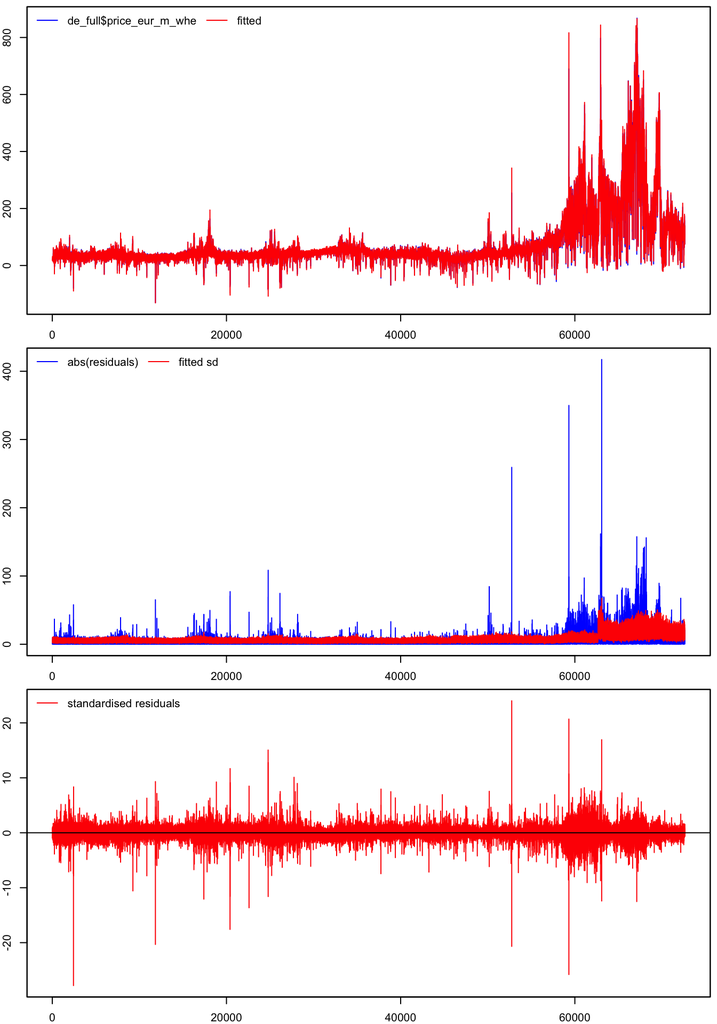

```r
esc_de_shares_sel_inds %>% plot
```

## (TBA) Spotlight on UK, Germany, Denmark

Here, see the time series for Germany and Denmark (to compare to the data avialable in Rintamaki et al. - color portion of the TS plots). UK spotlight to discuss potential interest to David.

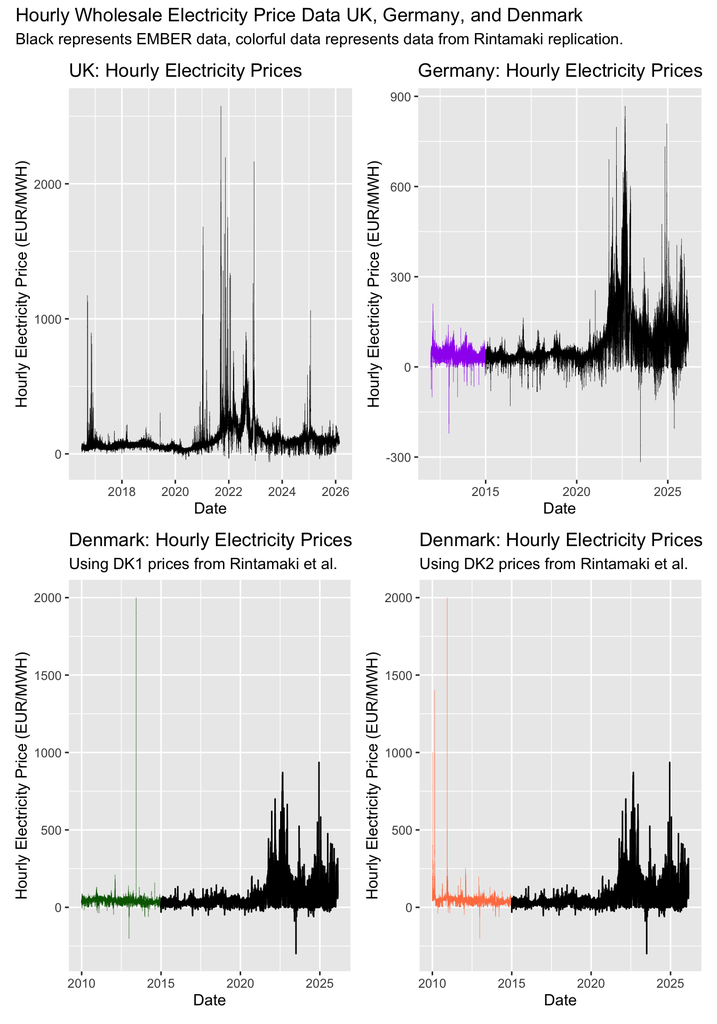

## (TBA) Full Extension to Europe

Note: Recall also that you can find our replication of [Rintamaki et al.](https://doi.org/10.1016/j.eneco.2016.12.019) [here](https://ebbam.github.io/ren_vol/code/rintamaki_replication/rintamaki_replication.html). We have yet to analyse the differences between the hourly volatility specification using getsv() versus the Rintamaki results.

### Hourly Prices

Using data from [EMBER](https://ember-energy.org/data/european-wholesale-electricity-price-data/) on European wholesale electricity prices (hourly - daily and monthly also exist), The hourly prices are the day-ahead wholesale prices by country.

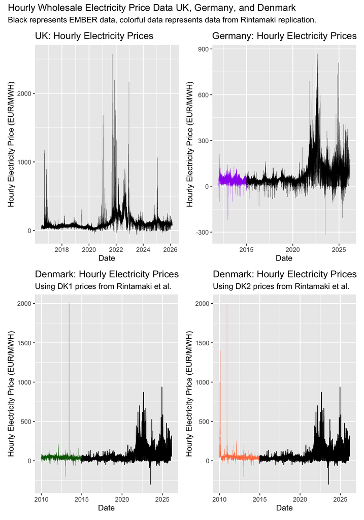

The following is data from [ENTSO-E](https://www.entsoe.eu/data/power-stats/) on hourly electricity loads.

```
## [1] TRUE
```

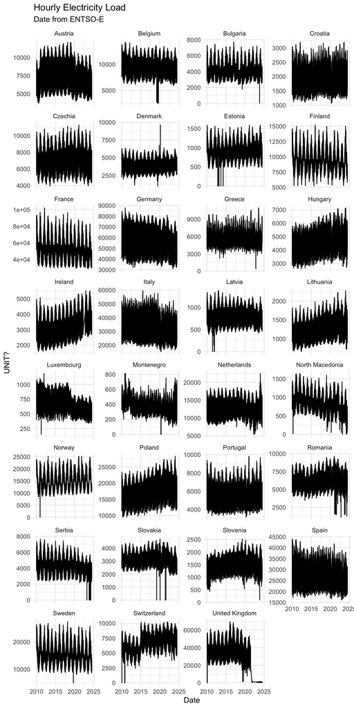

### Daily and Monthly Prices

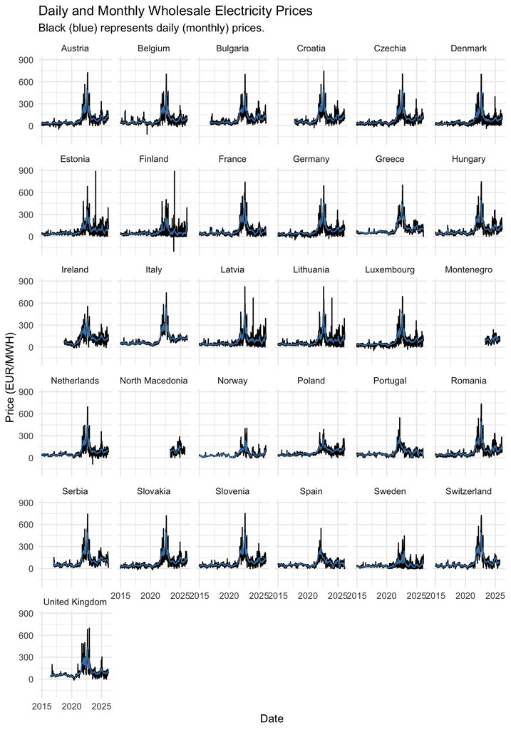

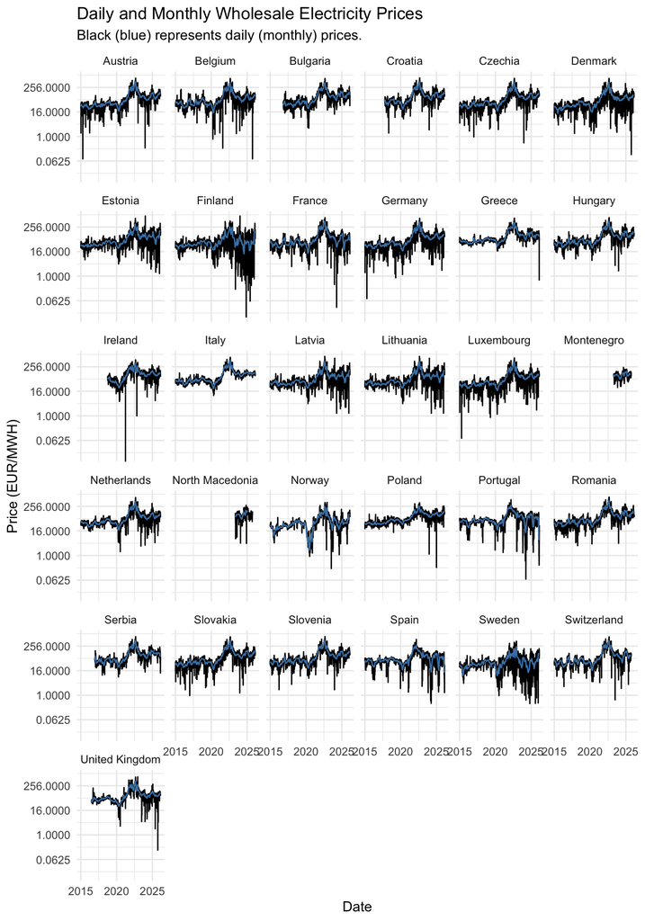